# examples_0206

On the right triangle below, find the unknown length or angle (in degrees).

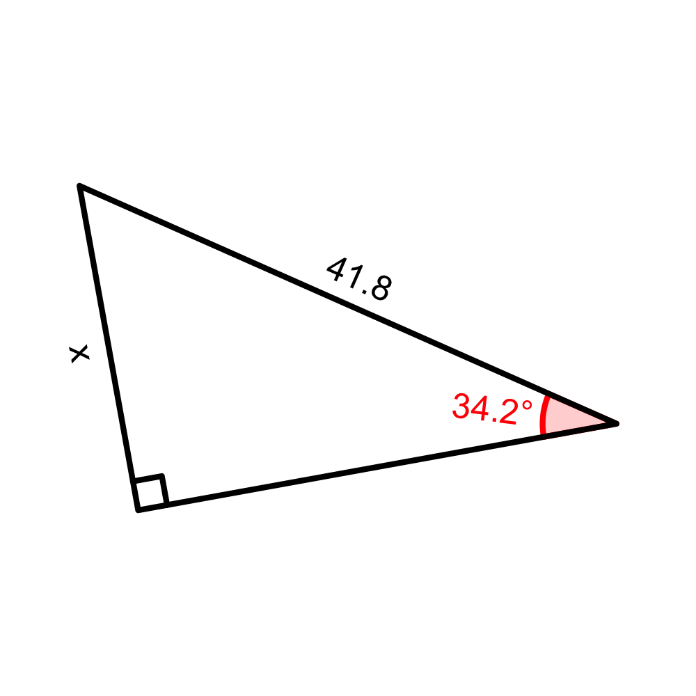

The tolerance is $\pm 0.1$.

Remember pythagorean theorem (for finding a side length from the other two side lengths).

$$(\text{adj})^2+(\text{opp})^2=(\text{hyp})^2$$

Remember SOH-CAH-TOA (for relating side-length ratios to angles).

$$\sin(\theta)=\frac{\text{opp}}{\text{hyp}}$$
$$\cos(\theta)=\frac{\text{adj}}{\text{hyp}}$$
$$\tan(\theta)=\frac{\text{opp}}{\text{adj}}$$

Use the appropriate equation.

$$\sin(34.2)=\frac{x}{41.8}$$
$$x=41.8\cdot\sin(34.2)$$

$$x=23.5$$

On the right triangle below, find the unknown length or angle (in degrees).

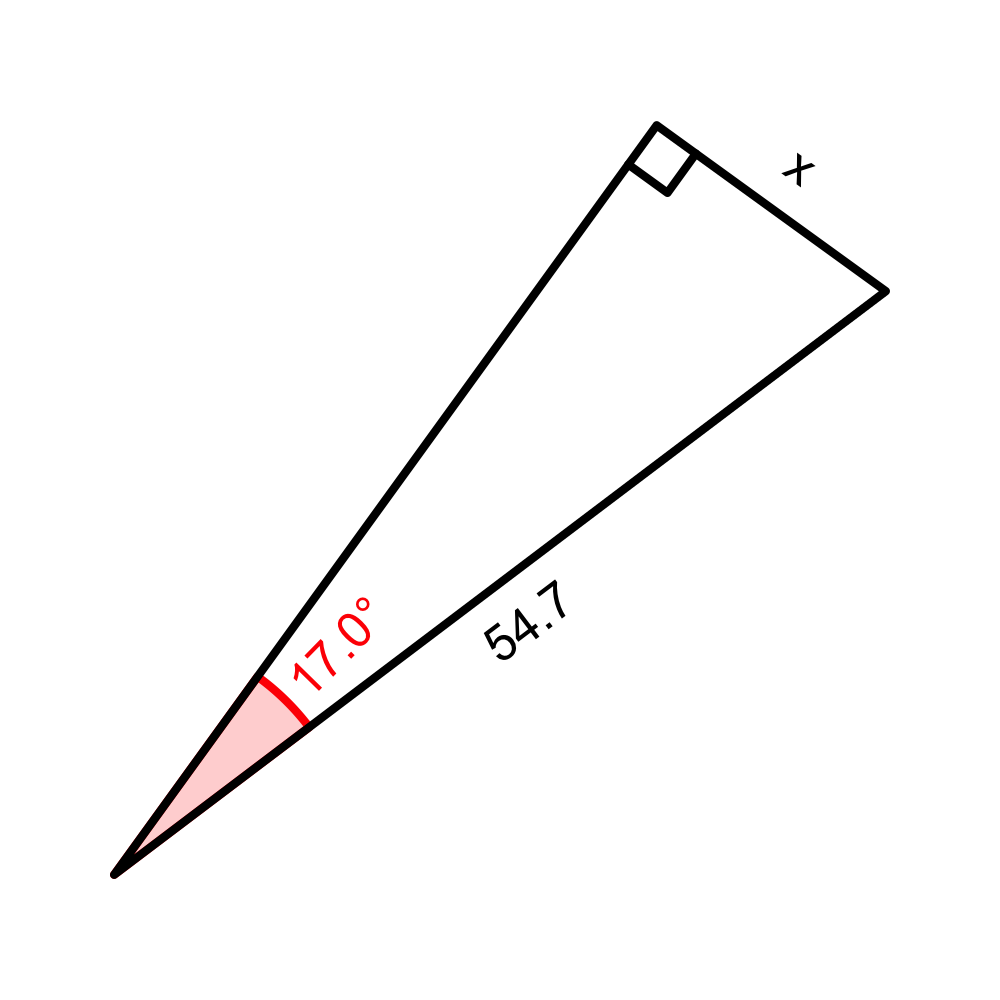

The tolerance is $\pm 0.1$.

Remember pythagorean theorem (for finding a side length from the other two side lengths).

$$(\text{adj})^2+(\text{opp})^2=(\text{hyp})^2$$

Remember SOH-CAH-TOA (for relating side-length ratios to angles).

$$\sin(\theta)=\frac{\text{opp}}{\text{hyp}}$$
$$\cos(\theta)=\frac{\text{adj}}{\text{hyp}}$$
$$\tan(\theta)=\frac{\text{opp}}{\text{adj}}$$

Use the appropriate equation.

$$\sin(17)=\frac{x}{54.7}$$
$$x=54.7\cdot\sin(17)$$

$$x=16$$

On the right triangle below, find the unknown length or angle (in degrees).

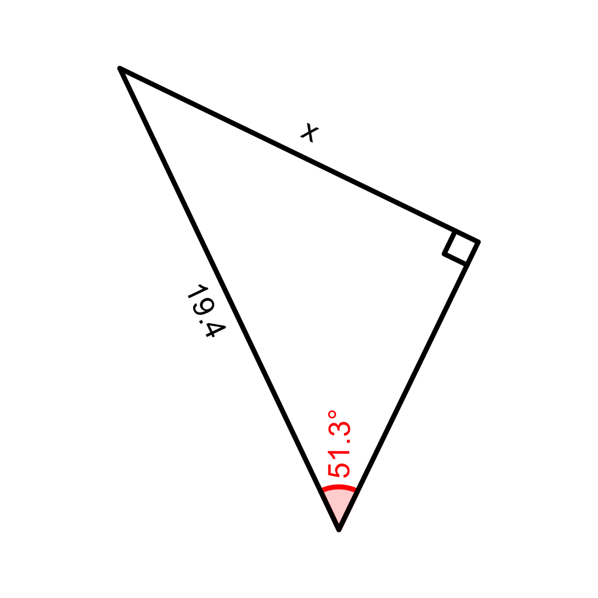

The tolerance is $\pm 0.1$.

Remember pythagorean theorem (for finding a side length from the other two side lengths).

$$(\text{adj})^2+(\text{opp})^2=(\text{hyp})^2$$

Remember SOH-CAH-TOA (for relating side-length ratios to angles).

$$\sin(\theta)=\frac{\text{opp}}{\text{hyp}}$$
$$\cos(\theta)=\frac{\text{adj}}{\text{hyp}}$$
$$\tan(\theta)=\frac{\text{opp}}{\text{adj}}$$

Use the appropriate equation.

$$\sin(51.3)=\frac{x}{19.4}$$
$$x=19.4\cdot\sin(51.3)$$

$$x=15.1$$

On the right triangle below, find the unknown length or angle (in degrees).

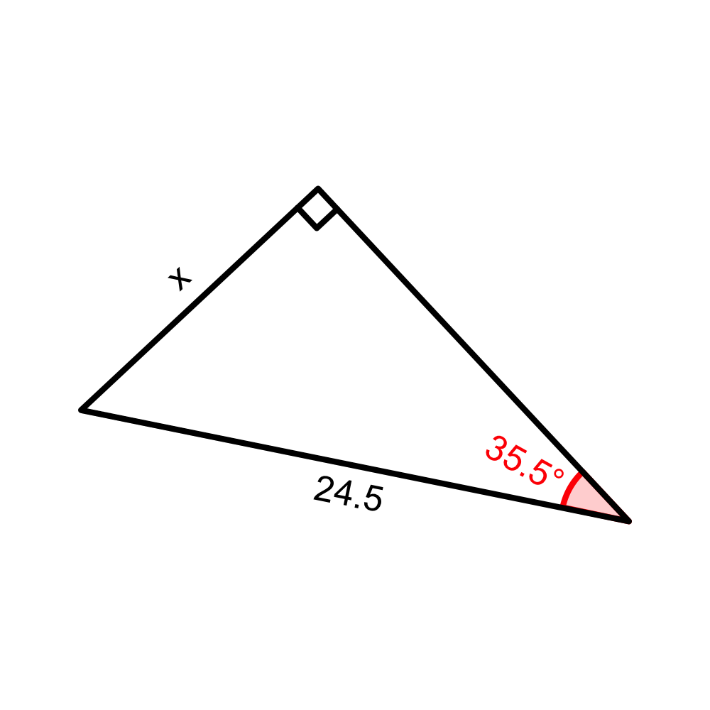

The tolerance is $\pm 0.1$.

Remember pythagorean theorem (for finding a side length from the other two side lengths).

$$(\text{adj})^2+(\text{opp})^2=(\text{hyp})^2$$

Remember SOH-CAH-TOA (for relating side-length ratios to angles).

$$\sin(\theta)=\frac{\text{opp}}{\text{hyp}}$$
$$\cos(\theta)=\frac{\text{adj}}{\text{hyp}}$$
$$\tan(\theta)=\frac{\text{opp}}{\text{adj}}$$

Use the appropriate equation.

$$\sin(35.5)=\frac{x}{24.5}$$
$$x=24.5\cdot\sin(35.5)$$

$$x=14.2$$

On the right triangle below, find the unknown length or angle (in degrees).

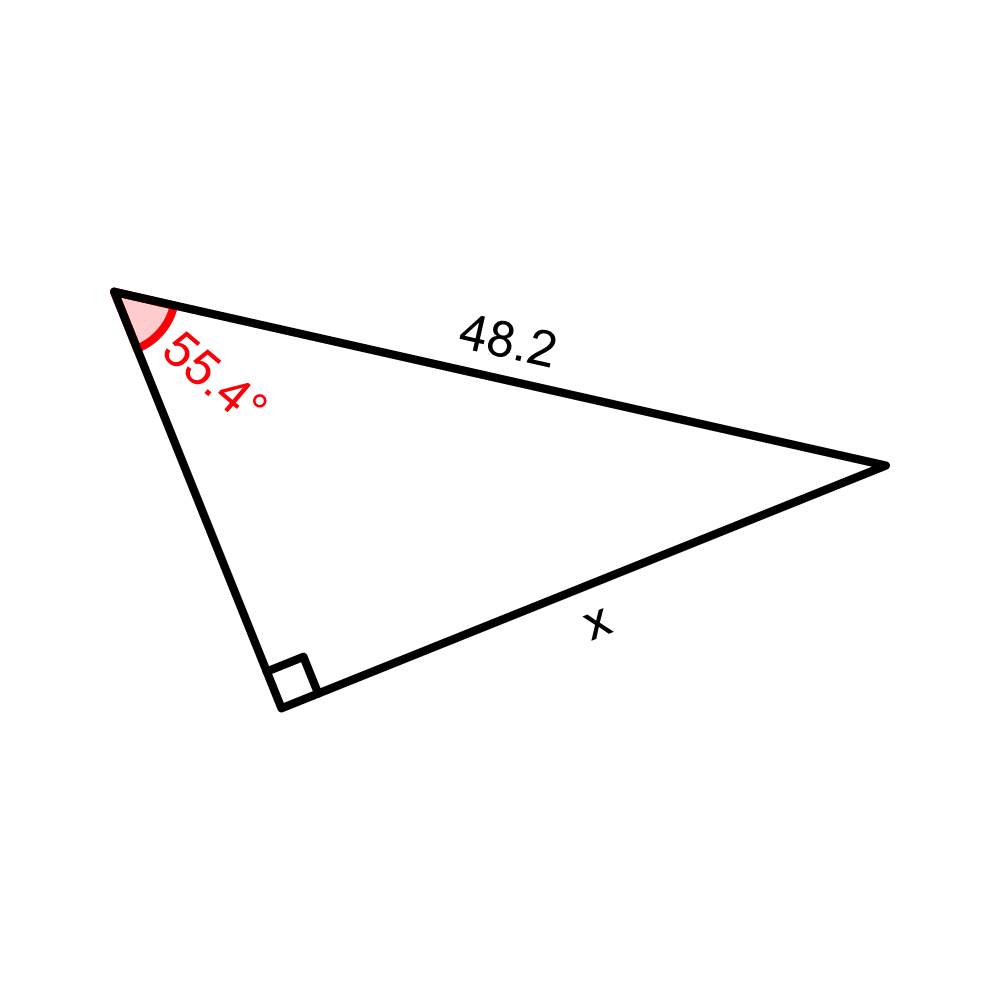

The tolerance is $\pm 0.1$.

Remember pythagorean theorem (for finding a side length from the other two side lengths).

$$(\text{adj})^2+(\text{opp})^2=(\text{hyp})^2$$

Remember SOH-CAH-TOA (for relating side-length ratios to angles).

$$\sin(\theta)=\frac{\text{opp}}{\text{hyp}}$$
$$\cos(\theta)=\frac{\text{adj}}{\text{hyp}}$$
$$\tan(\theta)=\frac{\text{opp}}{\text{adj}}$$

Use the appropriate equation.

$$\sin(55.4)=\frac{x}{48.2}$$
$$x=48.2\cdot\sin(55.4)$$

$$x=39.7$$

On the right triangle below, find the unknown length or angle (in degrees).

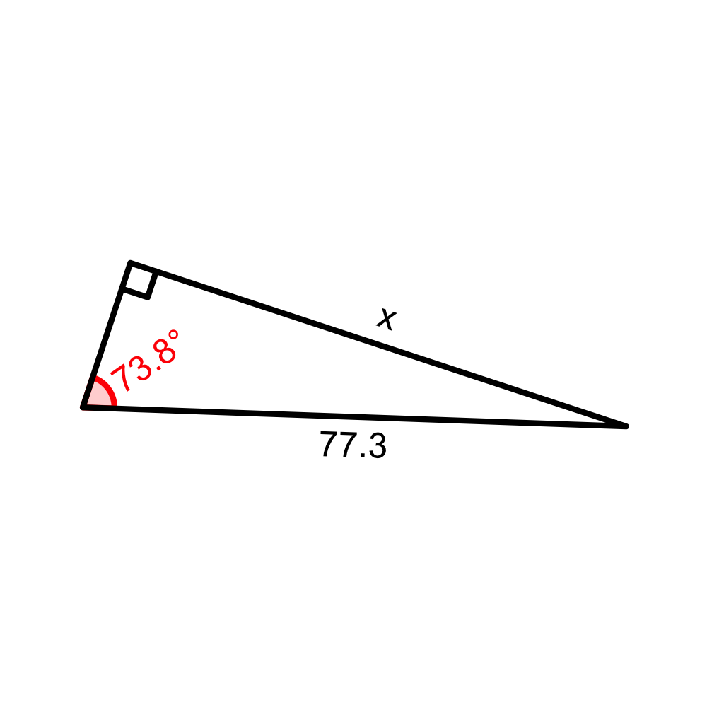

The tolerance is $\pm 0.1$.

Remember pythagorean theorem (for finding a side length from the other two side lengths).

$$(\text{adj})^2+(\text{opp})^2=(\text{hyp})^2$$

Remember SOH-CAH-TOA (for relating side-length ratios to angles).

$$\sin(\theta)=\frac{\text{opp}}{\text{hyp}}$$
$$\cos(\theta)=\frac{\text{adj}}{\text{hyp}}$$
$$\tan(\theta)=\frac{\text{opp}}{\text{adj}}$$

Use the appropriate equation.

$$\sin(73.8)=\frac{x}{77.3}$$
$$x=77.3\cdot\sin(73.8)$$

$$x=74.2$$

On the right triangle below, find the unknown length or angle (in degrees).

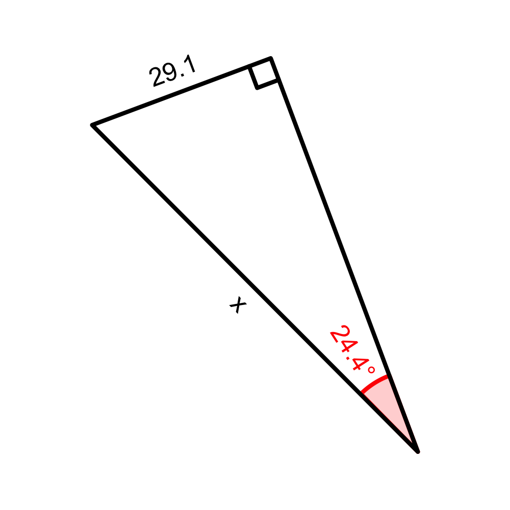

The tolerance is $\pm 0.1$.

Remember pythagorean theorem (for finding a side length from the other two side lengths).

$$(\text{adj})^2+(\text{opp})^2=(\text{hyp})^2$$

Remember SOH-CAH-TOA (for relating side-length ratios to angles).

$$\sin(\theta)=\frac{\text{opp}}{\text{hyp}}$$
$$\cos(\theta)=\frac{\text{adj}}{\text{hyp}}$$
$$\tan(\theta)=\frac{\text{opp}}{\text{adj}}$$

Use the appropriate equation.

$$\sin(24.4)=\frac{29.1}{x}$$
$$x=\frac{29.1}{\sin(24.4)}$$

$$x=70.4$$

On the right triangle below, find the unknown length or angle (in degrees).

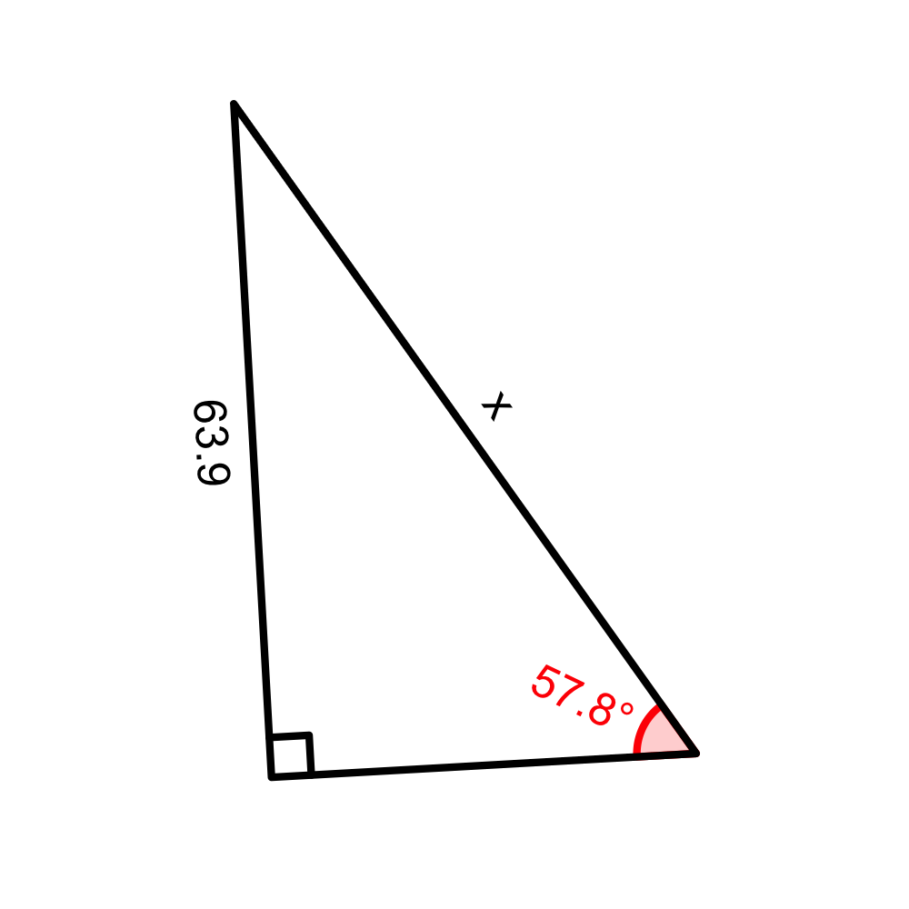

The tolerance is $\pm 0.1$.

Remember pythagorean theorem (for finding a side length from the other two side lengths).

$$(\text{adj})^2+(\text{opp})^2=(\text{hyp})^2$$

Remember SOH-CAH-TOA (for relating side-length ratios to angles).

$$\sin(\theta)=\frac{\text{opp}}{\text{hyp}}$$
$$\cos(\theta)=\frac{\text{adj}}{\text{hyp}}$$
$$\tan(\theta)=\frac{\text{opp}}{\text{adj}}$$

Use the appropriate equation.

$$\sin(57.8)=\frac{63.9}{x}$$
$$x=\frac{63.9}{\sin(57.8)}$$

$$x=75.5$$

On the right triangle below, find the unknown length or angle (in degrees).

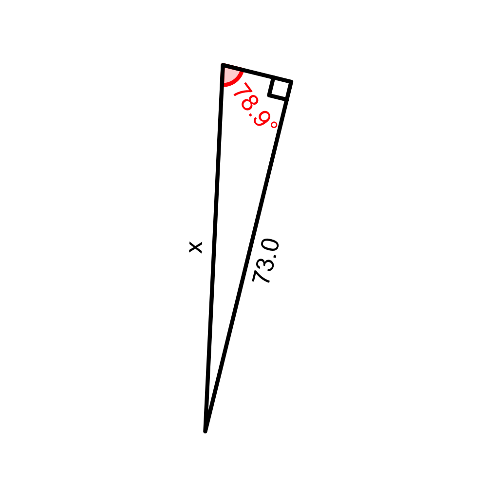

The tolerance is $\pm 0.1$.

Remember pythagorean theorem (for finding a side length from the other two side lengths).

$$(\text{adj})^2+(\text{opp})^2=(\text{hyp})^2$$

Remember SOH-CAH-TOA (for relating side-length ratios to angles).

$$\sin(\theta)=\frac{\text{opp}}{\text{hyp}}$$
$$\cos(\theta)=\frac{\text{adj}}{\text{hyp}}$$
$$\tan(\theta)=\frac{\text{opp}}{\text{adj}}$$

Use the appropriate equation.

$$\sin(78.9)=\frac{73}{x}$$
$$x=\frac{73}{\sin(78.9)}$$

$$x=74.4$$

On the right triangle below, find the unknown length or angle (in degrees).

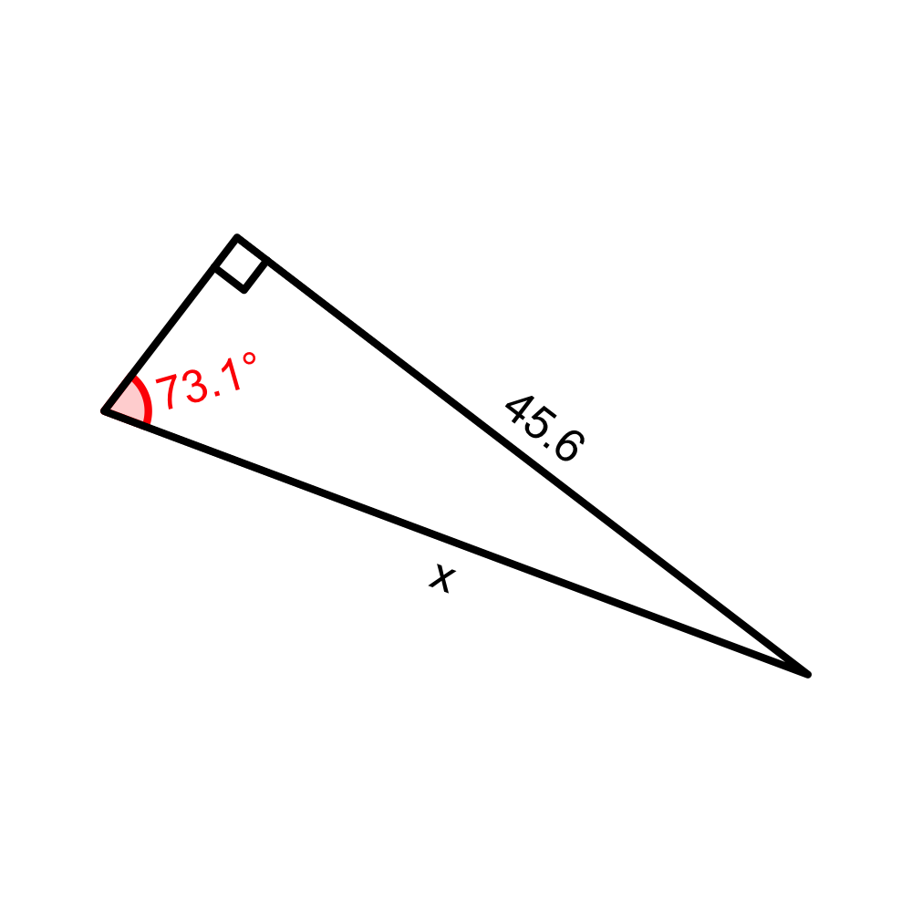

The tolerance is $\pm 0.1$.

Remember pythagorean theorem (for finding a side length from the other two side lengths).

$$(\text{adj})^2+(\text{opp})^2=(\text{hyp})^2$$

Remember SOH-CAH-TOA (for relating side-length ratios to angles).

$$\sin(\theta)=\frac{\text{opp}}{\text{hyp}}$$
$$\cos(\theta)=\frac{\text{adj}}{\text{hyp}}$$
$$\tan(\theta)=\frac{\text{opp}}{\text{adj}}$$

Use the appropriate equation.

$$\sin(73.1)=\frac{45.6}{x}$$
$$x=\frac{45.6}{\sin(73.1)}$$

$$x=47.7$$

On the right triangle below, find the unknown length or angle (in degrees).

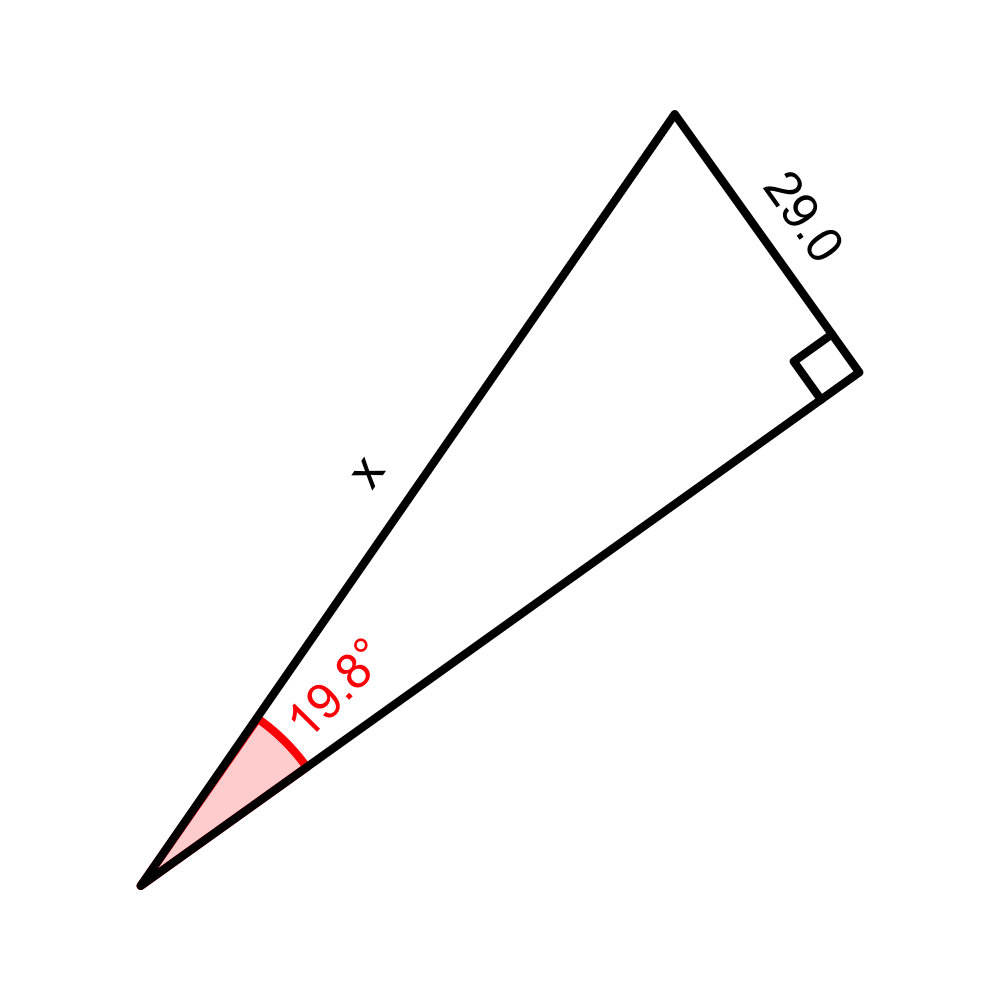

The tolerance is $\pm 0.1$.

Remember pythagorean theorem (for finding a side length from the other two side lengths).

$$(\text{adj})^2+(\text{opp})^2=(\text{hyp})^2$$

Remember SOH-CAH-TOA (for relating side-length ratios to angles).

$$\sin(\theta)=\frac{\text{opp}}{\text{hyp}}$$
$$\cos(\theta)=\frac{\text{adj}}{\text{hyp}}$$
$$\tan(\theta)=\frac{\text{opp}}{\text{adj}}$$

Use the appropriate equation.

$$\sin(19.8)=\frac{29}{x}$$
$$x=\frac{29}{\sin(19.8)}$$

$$x=85.6$$

On the right triangle below, find the unknown length or angle (in degrees).

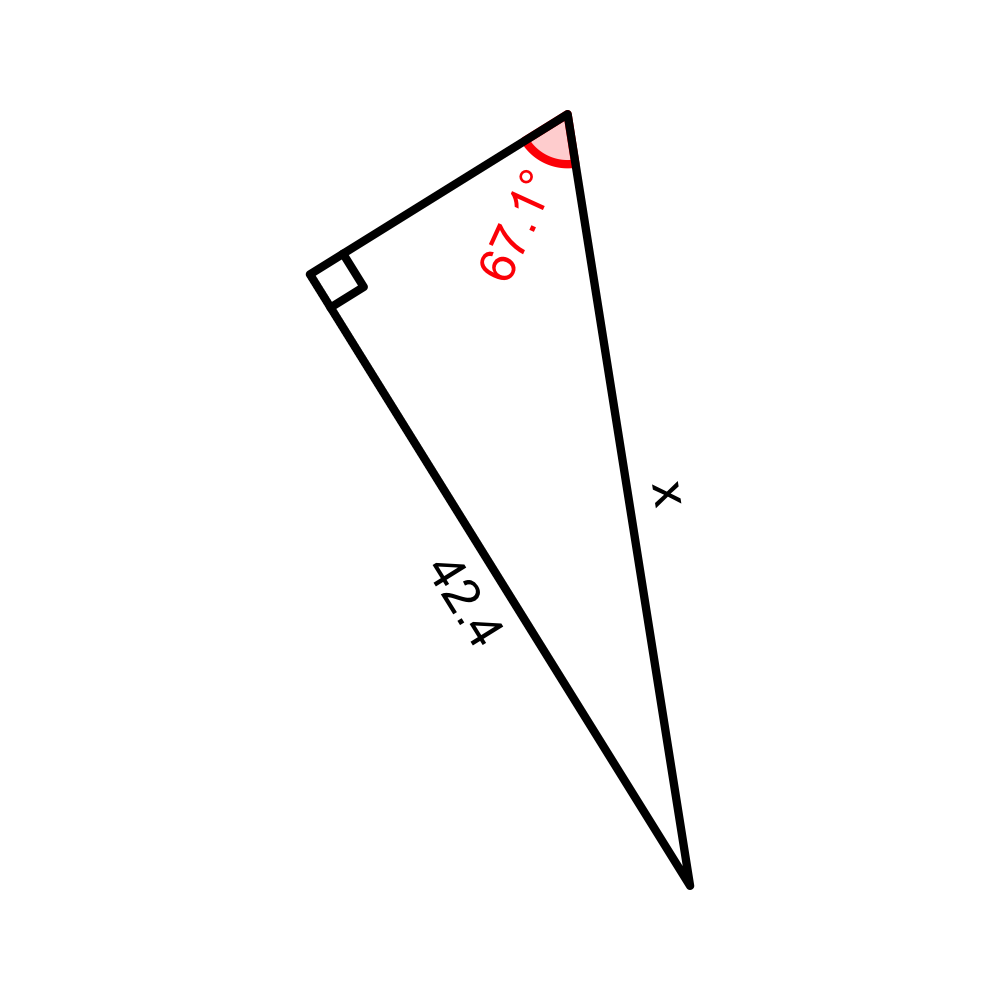

The tolerance is $\pm 0.1$.

Remember pythagorean theorem (for finding a side length from the other two side lengths).

$$(\text{adj})^2+(\text{opp})^2=(\text{hyp})^2$$

Remember SOH-CAH-TOA (for relating side-length ratios to angles).

$$\sin(\theta)=\frac{\text{opp}}{\text{hyp}}$$
$$\cos(\theta)=\frac{\text{adj}}{\text{hyp}}$$
$$\tan(\theta)=\frac{\text{opp}}{\text{adj}}$$

Use the appropriate equation.

$$\sin(67.1)=\frac{42.4}{x}$$
$$x=\frac{42.4}{\sin(67.1)}$$

$$x=46$$

On the right triangle below, find the unknown length or angle (in degrees).

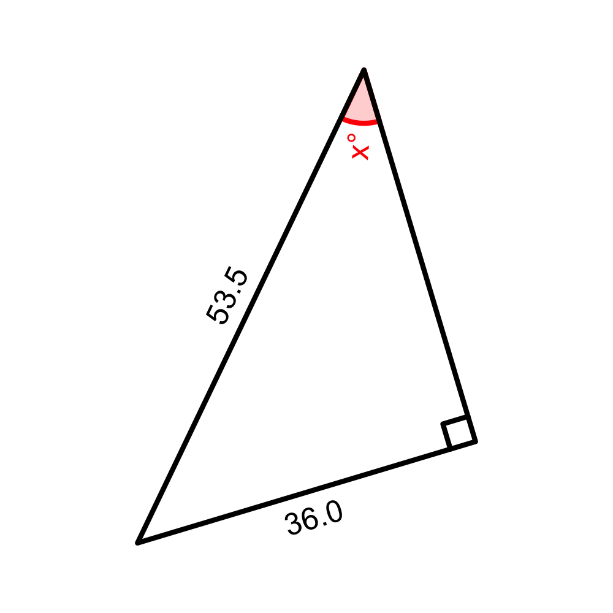

The tolerance is $\pm 0.1$.

Remember pythagorean theorem (for finding a side length from the other two side lengths).

$$(\text{adj})^2+(\text{opp})^2=(\text{hyp})^2$$

Remember SOH-CAH-TOA (for relating side-length ratios to angles).

$$\sin(\theta)=\frac{\text{opp}}{\text{hyp}}$$
$$\cos(\theta)=\frac{\text{adj}}{\text{hyp}}$$
$$\tan(\theta)=\frac{\text{opp}}{\text{adj}}$$

Use the appropriate equation.

$$\sin(x)=\frac{36}{53.5}$$
$$x=\arcsin\left(\frac{36}{53.5}\right)$$

$$x=42.3$$

On the right triangle below, find the unknown length or angle (in degrees).

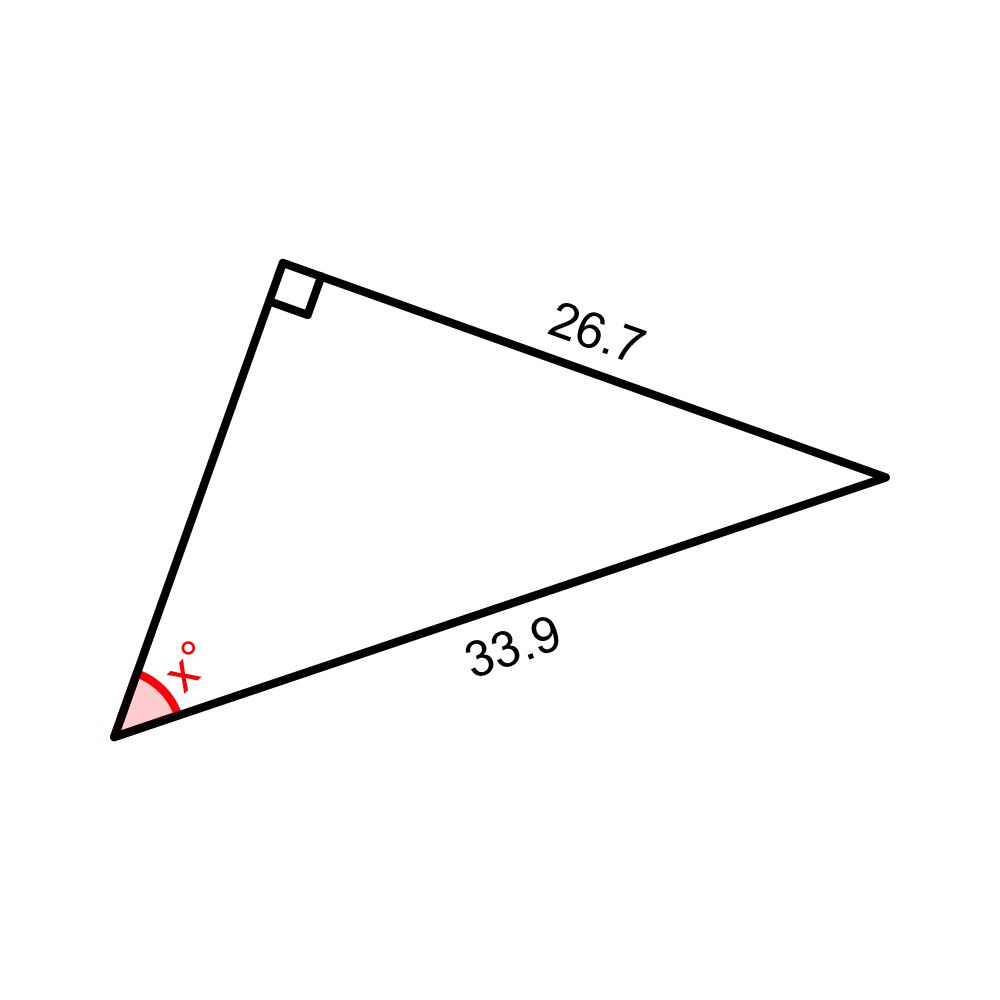

The tolerance is $\pm 0.1$.

Remember pythagorean theorem (for finding a side length from the other two side lengths).

$$(\text{adj})^2+(\text{opp})^2=(\text{hyp})^2$$

Remember SOH-CAH-TOA (for relating side-length ratios to angles).

$$\sin(\theta)=\frac{\text{opp}}{\text{hyp}}$$
$$\cos(\theta)=\frac{\text{adj}}{\text{hyp}}$$
$$\tan(\theta)=\frac{\text{opp}}{\text{adj}}$$

Use the appropriate equation.

$$\sin(x)=\frac{26.7}{33.9}$$
$$x=\arcsin\left(\frac{26.7}{33.9}\right)$$

$$x=52$$

On the right triangle below, find the unknown length or angle (in degrees).

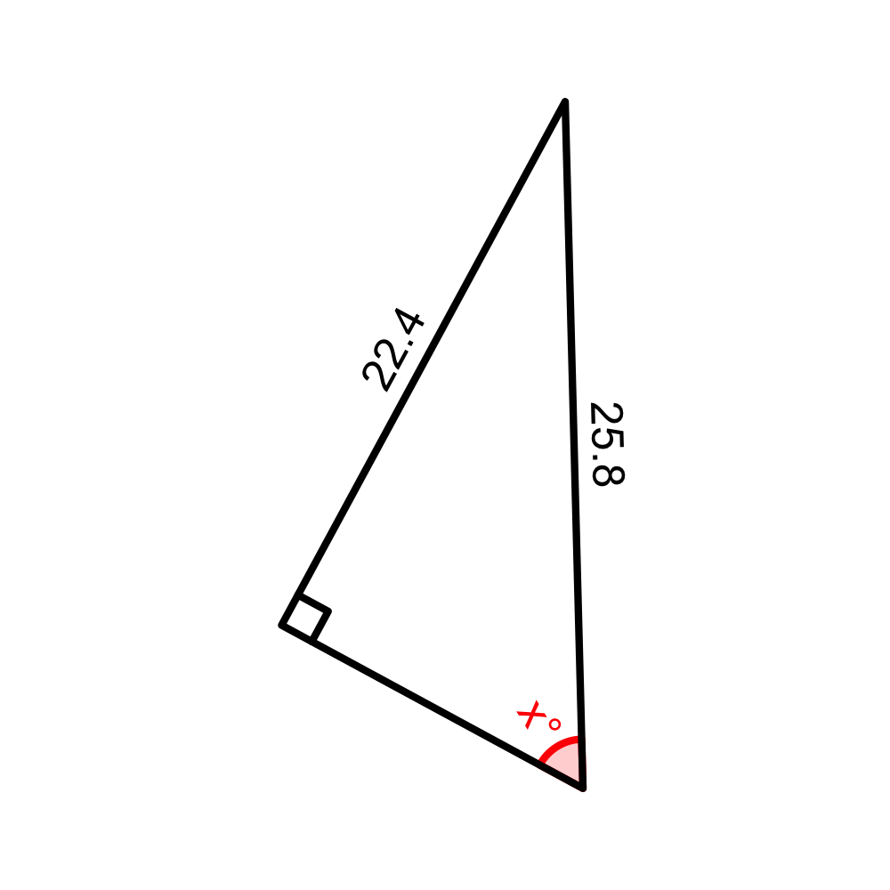

The tolerance is $\pm 0.1$.

Remember pythagorean theorem (for finding a side length from the other two side lengths).

$$(\text{adj})^2+(\text{opp})^2=(\text{hyp})^2$$

Remember SOH-CAH-TOA (for relating side-length ratios to angles).

$$\sin(\theta)=\frac{\text{opp}}{\text{hyp}}$$
$$\cos(\theta)=\frac{\text{adj}}{\text{hyp}}$$
$$\tan(\theta)=\frac{\text{opp}}{\text{adj}}$$

Use the appropriate equation.

$$\sin(x)=\frac{22.4}{25.8}$$
$$x=\arcsin\left(\frac{22.4}{25.8}\right)$$

$$x=60.3$$

On the right triangle below, find the unknown length or angle (in degrees).

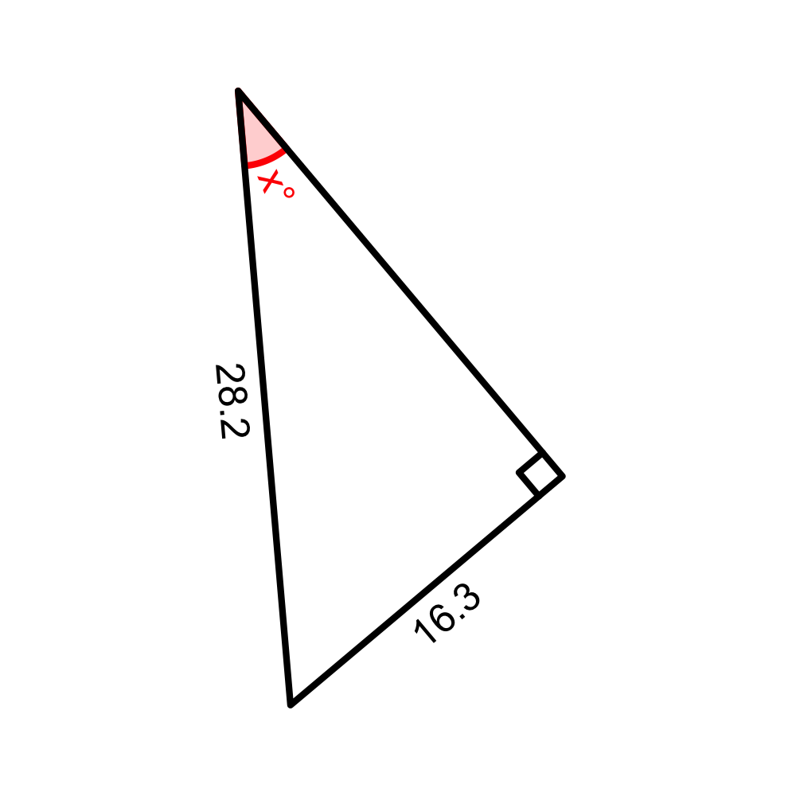

The tolerance is $\pm 0.1$.

Remember pythagorean theorem (for finding a side length from the other two side lengths).

$$(\text{adj})^2+(\text{opp})^2=(\text{hyp})^2$$

Remember SOH-CAH-TOA (for relating side-length ratios to angles).

$$\sin(\theta)=\frac{\text{opp}}{\text{hyp}}$$
$$\cos(\theta)=\frac{\text{adj}}{\text{hyp}}$$
$$\tan(\theta)=\frac{\text{opp}}{\text{adj}}$$

Use the appropriate equation.

$$\sin(x)=\frac{16.3}{28.2}$$
$$x=\arcsin\left(\frac{16.3}{28.2}\right)$$

$$x=35.3$$

On the right triangle below, find the unknown length or angle (in degrees).

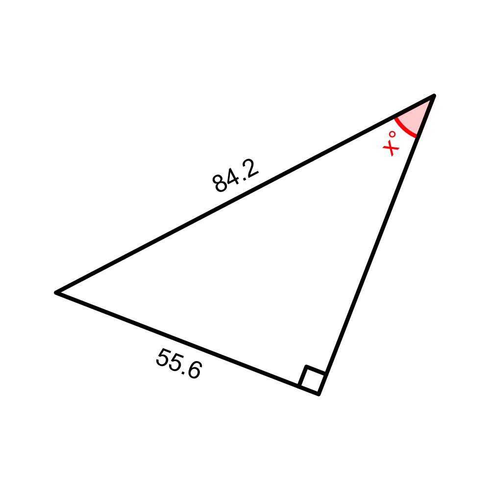

The tolerance is $\pm 0.1$.

Remember pythagorean theorem (for finding a side length from the other two side lengths).

$$(\text{adj})^2+(\text{opp})^2=(\text{hyp})^2$$

Remember SOH-CAH-TOA (for relating side-length ratios to angles).

$$\sin(\theta)=\frac{\text{opp}}{\text{hyp}}$$
$$\cos(\theta)=\frac{\text{adj}}{\text{hyp}}$$
$$\tan(\theta)=\frac{\text{opp}}{\text{adj}}$$

Use the appropriate equation.

$$\sin(x)=\frac{55.6}{84.2}$$
$$x=\arcsin\left(\frac{55.6}{84.2}\right)$$

$$x=41.3$$

On the right triangle below, find the unknown length or angle (in degrees).

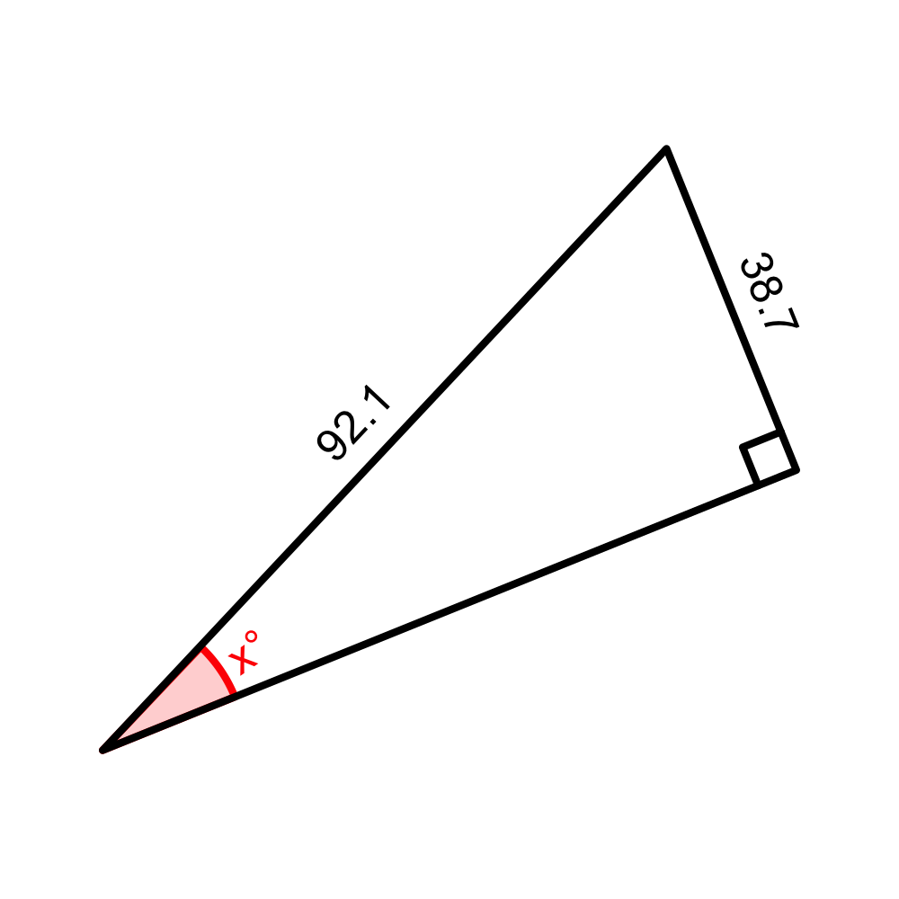

The tolerance is $\pm 0.1$.

Remember pythagorean theorem (for finding a side length from the other two side lengths).

$$(\text{adj})^2+(\text{opp})^2=(\text{hyp})^2$$

Remember SOH-CAH-TOA (for relating side-length ratios to angles).

$$\sin(\theta)=\frac{\text{opp}}{\text{hyp}}$$
$$\cos(\theta)=\frac{\text{adj}}{\text{hyp}}$$
$$\tan(\theta)=\frac{\text{opp}}{\text{adj}}$$

Use the appropriate equation.

$$\sin(x)=\frac{38.7}{92.1}$$
$$x=\arcsin\left(\frac{38.7}{92.1}\right)$$

$$x=24.8$$

On the right triangle below, find the unknown length or angle (in degrees).

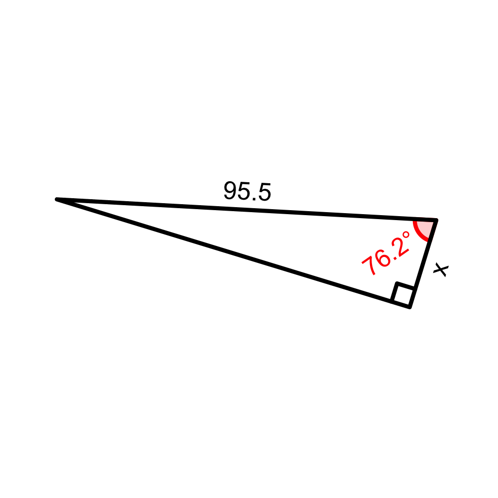

The tolerance is $\pm 0.1$.

Remember pythagorean theorem (for finding a side length from the other two side lengths).

$$(\text{adj})^2+(\text{opp})^2=(\text{hyp})^2$$

Remember SOH-CAH-TOA (for relating side-length ratios to angles).

$$\sin(\theta)=\frac{\text{opp}}{\text{hyp}}$$
$$\cos(\theta)=\frac{\text{adj}}{\text{hyp}}$$
$$\tan(\theta)=\frac{\text{opp}}{\text{adj}}$$

Use the appropriate equation.

$$\cos(76.2)=\frac{x}{95.5}$$
$$x=95.5\cdot\cos(76.2)$$

$$x=22.8$$

On the right triangle below, find the unknown length or angle (in degrees).

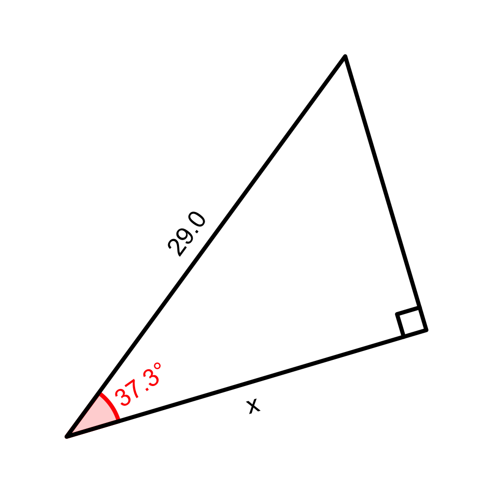

The tolerance is $\pm 0.1$.

Remember pythagorean theorem (for finding a side length from the other two side lengths).

$$(\text{adj})^2+(\text{opp})^2=(\text{hyp})^2$$

Remember SOH-CAH-TOA (for relating side-length ratios to angles).

$$\sin(\theta)=\frac{\text{opp}}{\text{hyp}}$$
$$\cos(\theta)=\frac{\text{adj}}{\text{hyp}}$$
$$\tan(\theta)=\frac{\text{opp}}{\text{adj}}$$

Use the appropriate equation.

$$\cos(37.3)=\frac{x}{29}$$
$$x=29\cdot\cos(37.3)$$

$$x=23.1$$

On the right triangle below, find the unknown length or angle (in degrees).

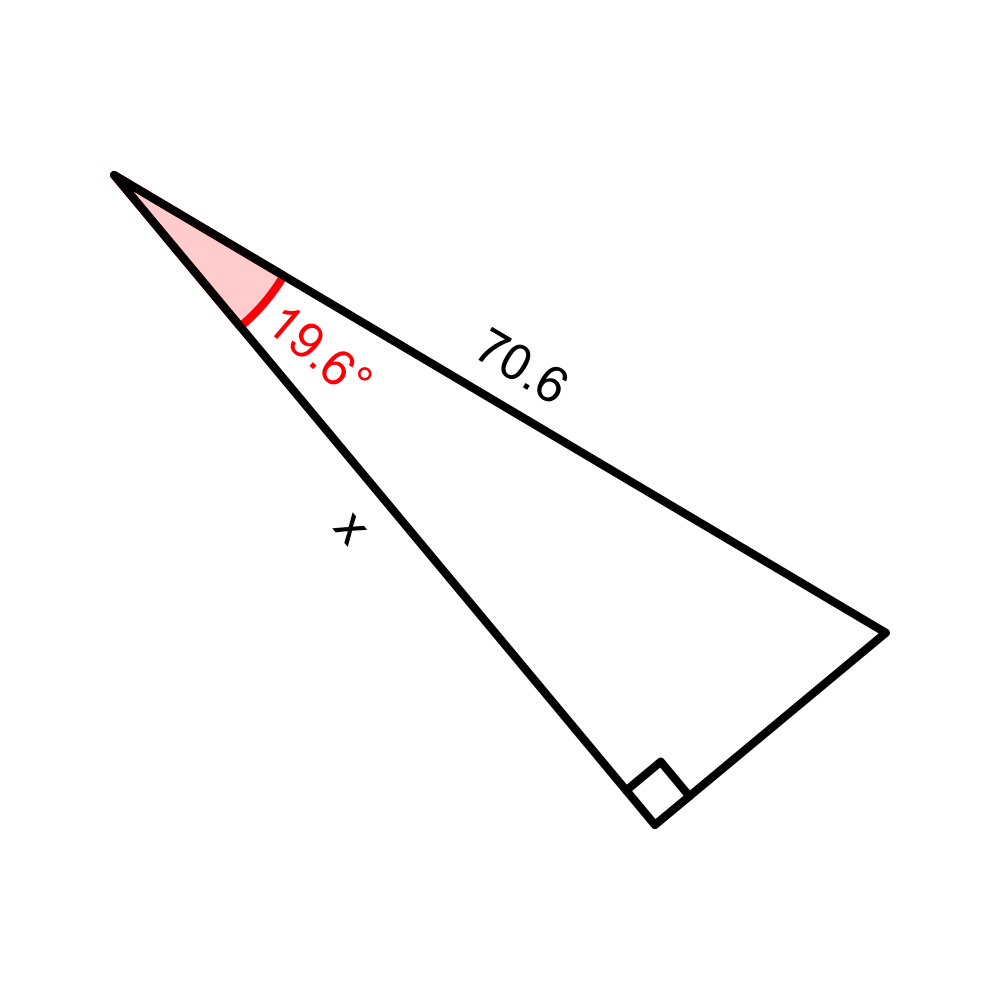

The tolerance is $\pm 0.1$.

Remember pythagorean theorem (for finding a side length from the other two side lengths).

$$(\text{adj})^2+(\text{opp})^2=(\text{hyp})^2$$

Remember SOH-CAH-TOA (for relating side-length ratios to angles).

$$\sin(\theta)=\frac{\text{opp}}{\text{hyp}}$$
$$\cos(\theta)=\frac{\text{adj}}{\text{hyp}}$$
$$\tan(\theta)=\frac{\text{opp}}{\text{adj}}$$

Use the appropriate equation.

$$\cos(19.6)=\frac{x}{70.6}$$
$$x=70.6\cdot\cos(19.6)$$

$$x=66.5$$

On the right triangle below, find the unknown length or angle (in degrees).

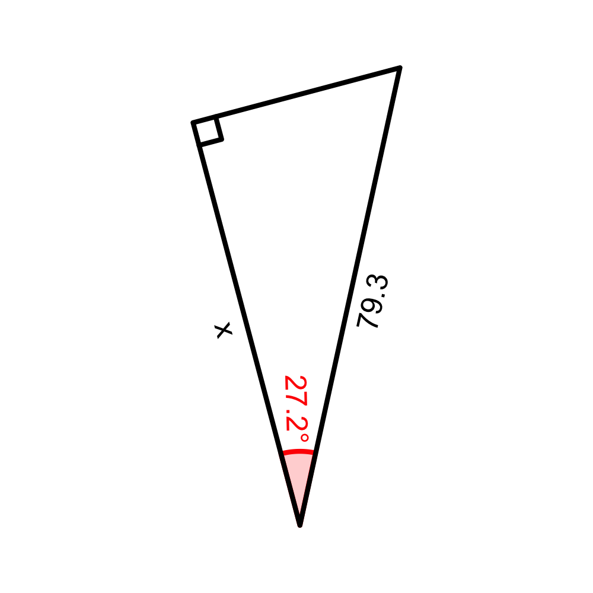

The tolerance is $\pm 0.1$.

Remember pythagorean theorem (for finding a side length from the other two side lengths).

$$(\text{adj})^2+(\text{opp})^2=(\text{hyp})^2$$

Remember SOH-CAH-TOA (for relating side-length ratios to angles).

$$\sin(\theta)=\frac{\text{opp}}{\text{hyp}}$$
$$\cos(\theta)=\frac{\text{adj}}{\text{hyp}}$$
$$\tan(\theta)=\frac{\text{opp}}{\text{adj}}$$

Use the appropriate equation.

$$\cos(27.2)=\frac{x}{79.3}$$
$$x=79.3\cdot\cos(27.2)$$

$$x=70.5$$

On the right triangle below, find the unknown length or angle (in degrees).

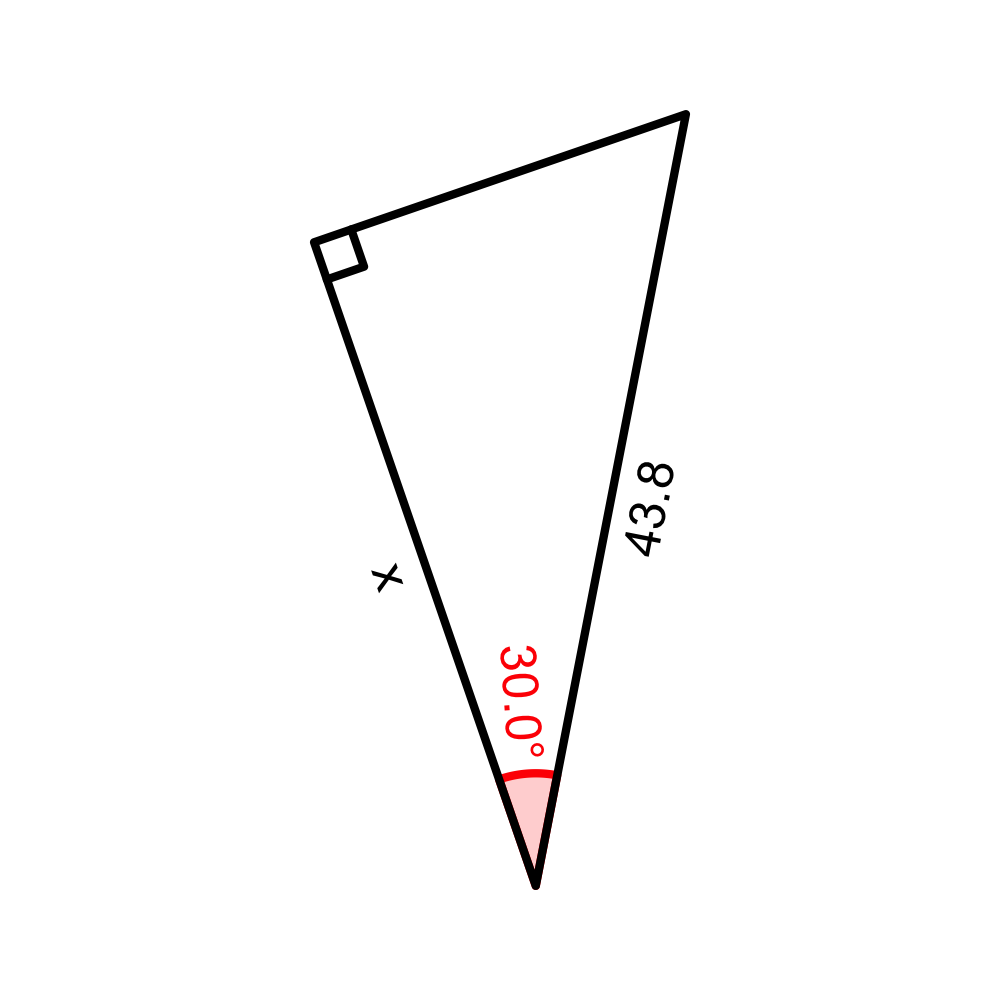

The tolerance is $\pm 0.1$.

Remember pythagorean theorem (for finding a side length from the other two side lengths).

$$(\text{adj})^2+(\text{opp})^2=(\text{hyp})^2$$

Remember SOH-CAH-TOA (for relating side-length ratios to angles).

$$\sin(\theta)=\frac{\text{opp}}{\text{hyp}}$$
$$\cos(\theta)=\frac{\text{adj}}{\text{hyp}}$$
$$\tan(\theta)=\frac{\text{opp}}{\text{adj}}$$

Use the appropriate equation.

$$\cos(30)=\frac{x}{43.8}$$
$$x=43.8\cdot\cos(30)$$

$$x=37.9$$

On the right triangle below, find the unknown length or angle (in degrees).

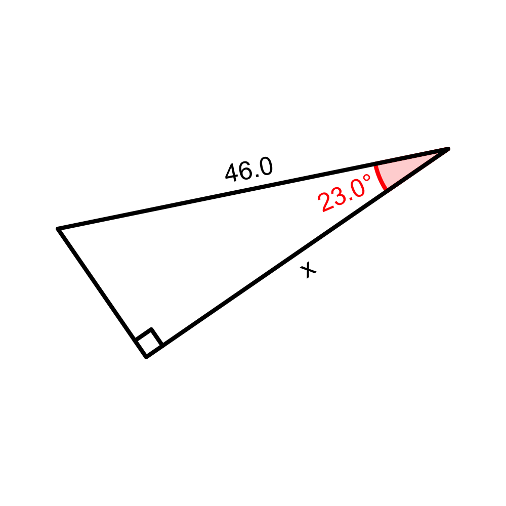

The tolerance is $\pm 0.1$.

Remember pythagorean theorem (for finding a side length from the other two side lengths).

$$(\text{adj})^2+(\text{opp})^2=(\text{hyp})^2$$

Remember SOH-CAH-TOA (for relating side-length ratios to angles).

$$\sin(\theta)=\frac{\text{opp}}{\text{hyp}}$$
$$\cos(\theta)=\frac{\text{adj}}{\text{hyp}}$$
$$\tan(\theta)=\frac{\text{opp}}{\text{adj}}$$

Use the appropriate equation.

$$\cos(23)=\frac{x}{46}$$
$$x=46\cdot\cos(23)$$

$$x=42.3$$

On the right triangle below, find the unknown length or angle (in degrees).

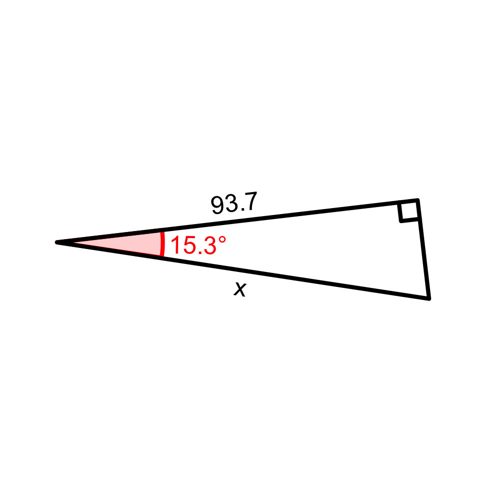

The tolerance is $\pm 0.1$.

Remember pythagorean theorem (for finding a side length from the other two side lengths).

$$(\text{adj})^2+(\text{opp})^2=(\text{hyp})^2$$

Remember SOH-CAH-TOA (for relating side-length ratios to angles).

$$\sin(\theta)=\frac{\text{opp}}{\text{hyp}}$$
$$\cos(\theta)=\frac{\text{adj}}{\text{hyp}}$$
$$\tan(\theta)=\frac{\text{opp}}{\text{adj}}$$

Use the appropriate equation.

$$\cos(15.3)=\frac{93.7}{x}$$
$$x=\frac{93.7}{\cos(15.3)}$$

$$x=97.1$$

On the right triangle below, find the unknown length or angle (in degrees).

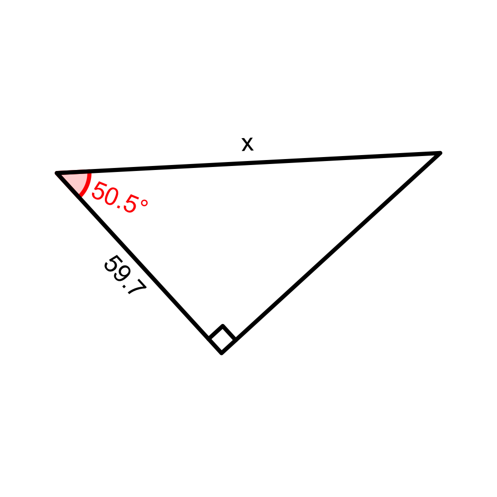

The tolerance is $\pm 0.1$.

Remember pythagorean theorem (for finding a side length from the other two side lengths).

$$(\text{adj})^2+(\text{opp})^2=(\text{hyp})^2$$

Remember SOH-CAH-TOA (for relating side-length ratios to angles).

$$\sin(\theta)=\frac{\text{opp}}{\text{hyp}}$$
$$\cos(\theta)=\frac{\text{adj}}{\text{hyp}}$$
$$\tan(\theta)=\frac{\text{opp}}{\text{adj}}$$

Use the appropriate equation.

$$\cos(50.5)=\frac{59.7}{x}$$
$$x=\frac{59.7}{\cos(50.5)}$$

$$x=93.9$$

On the right triangle below, find the unknown length or angle (in degrees).

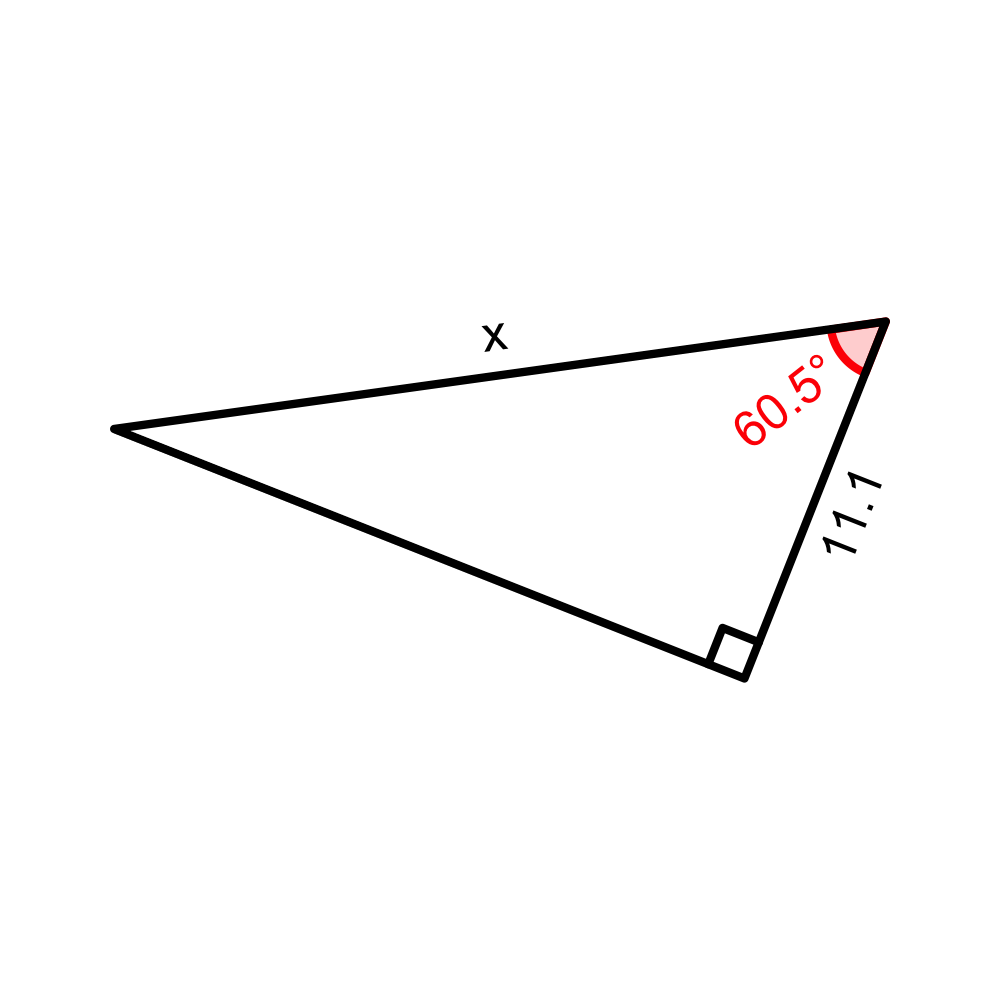

The tolerance is $\pm 0.1$.

Remember pythagorean theorem (for finding a side length from the other two side lengths).

$$(\text{adj})^2+(\text{opp})^2=(\text{hyp})^2$$

Remember SOH-CAH-TOA (for relating side-length ratios to angles).

$$\sin(\theta)=\frac{\text{opp}}{\text{hyp}}$$
$$\cos(\theta)=\frac{\text{adj}}{\text{hyp}}$$
$$\tan(\theta)=\frac{\text{opp}}{\text{adj}}$$

Use the appropriate equation.

$$\cos(60.5)=\frac{11.1}{x}$$
$$x=\frac{11.1}{\cos(60.5)}$$

$$x=22.5$$

On the right triangle below, find the unknown length or angle (in degrees).

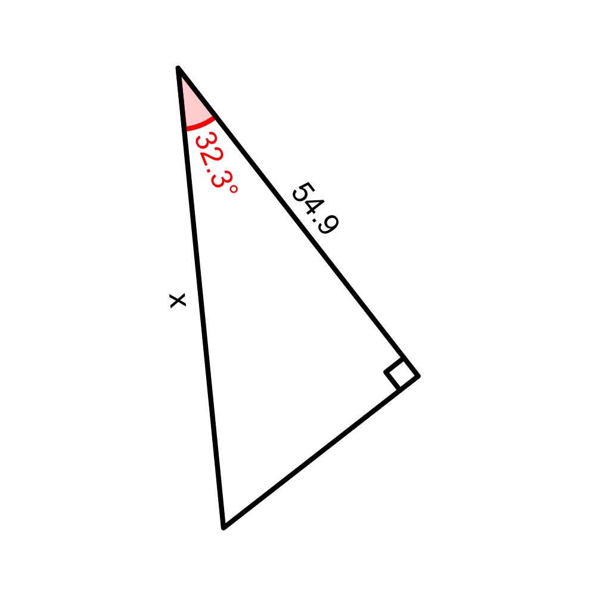

The tolerance is $\pm 0.1$.

Remember pythagorean theorem (for finding a side length from the other two side lengths).

$$(\text{adj})^2+(\text{opp})^2=(\text{hyp})^2$$

Remember SOH-CAH-TOA (for relating side-length ratios to angles).

$$\sin(\theta)=\frac{\text{opp}}{\text{hyp}}$$
$$\cos(\theta)=\frac{\text{adj}}{\text{hyp}}$$
$$\tan(\theta)=\frac{\text{opp}}{\text{adj}}$$

Use the appropriate equation.

$$\cos(32.3)=\frac{54.9}{x}$$
$$x=\frac{54.9}{\cos(32.3)}$$

$$x=65$$

On the right triangle below, find the unknown length or angle (in degrees).

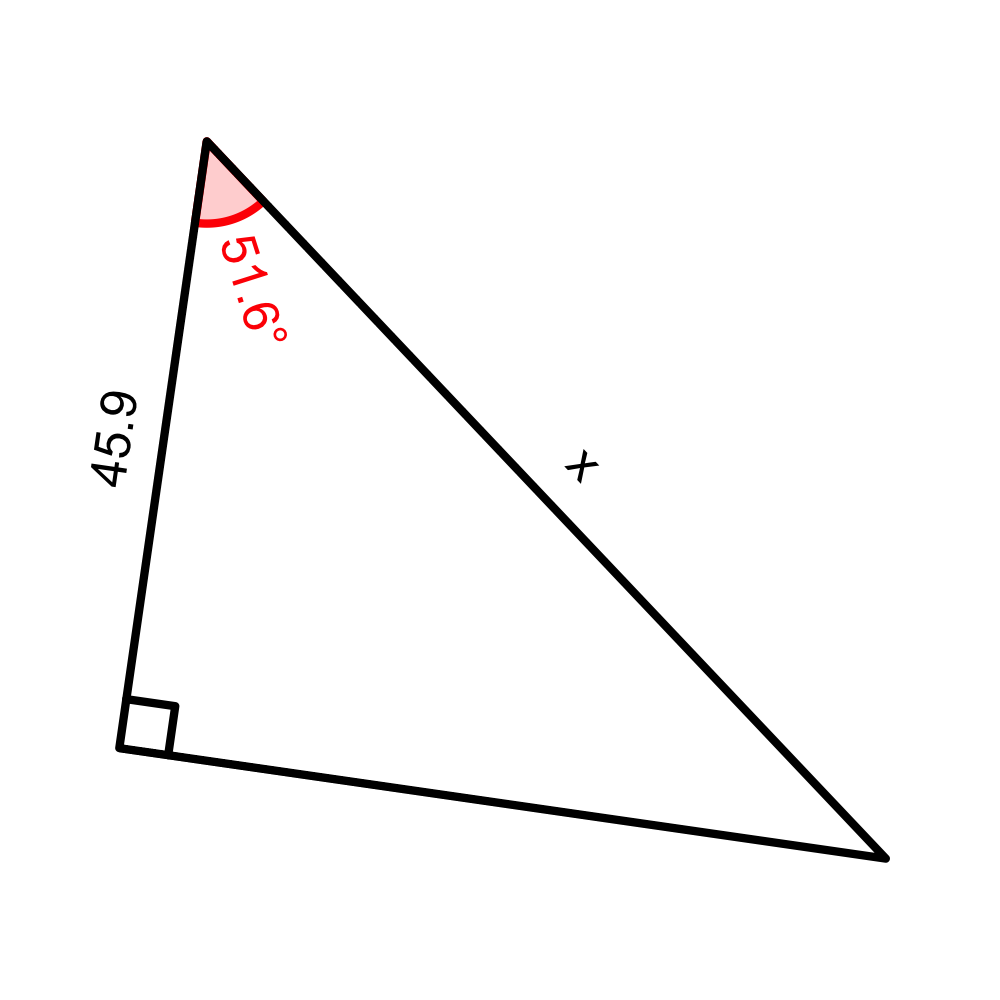

The tolerance is $\pm 0.1$.

Remember pythagorean theorem (for finding a side length from the other two side lengths).

$$(\text{adj})^2+(\text{opp})^2=(\text{hyp})^2$$

Remember SOH-CAH-TOA (for relating side-length ratios to angles).

$$\sin(\theta)=\frac{\text{opp}}{\text{hyp}}$$
$$\cos(\theta)=\frac{\text{adj}}{\text{hyp}}$$
$$\tan(\theta)=\frac{\text{opp}}{\text{adj}}$$

Use the appropriate equation.

$$\cos(51.6)=\frac{45.9}{x}$$
$$x=\frac{45.9}{\cos(51.6)}$$

$$x=73.9$$

On the right triangle below, find the unknown length or angle (in degrees).

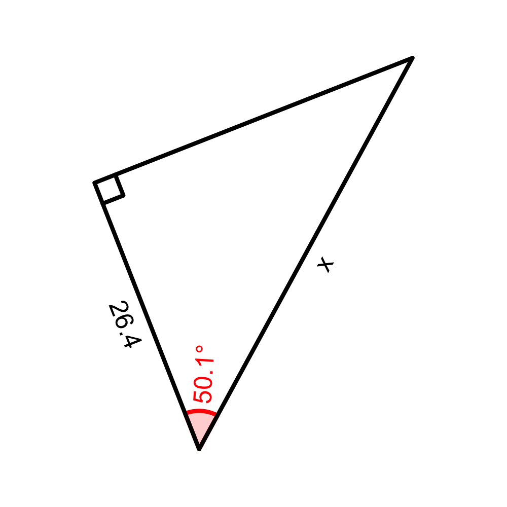

The tolerance is $\pm 0.1$.

Remember pythagorean theorem (for finding a side length from the other two side lengths).

$$(\text{adj})^2+(\text{opp})^2=(\text{hyp})^2$$

Remember SOH-CAH-TOA (for relating side-length ratios to angles).

$$\sin(\theta)=\frac{\text{opp}}{\text{hyp}}$$
$$\cos(\theta)=\frac{\text{adj}}{\text{hyp}}$$
$$\tan(\theta)=\frac{\text{opp}}{\text{adj}}$$

Use the appropriate equation.

$$\cos(50.1)=\frac{26.4}{x}$$
$$x=\frac{26.4}{\cos(50.1)}$$

$$x=41.2$$

On the right triangle below, find the unknown length or angle (in degrees).

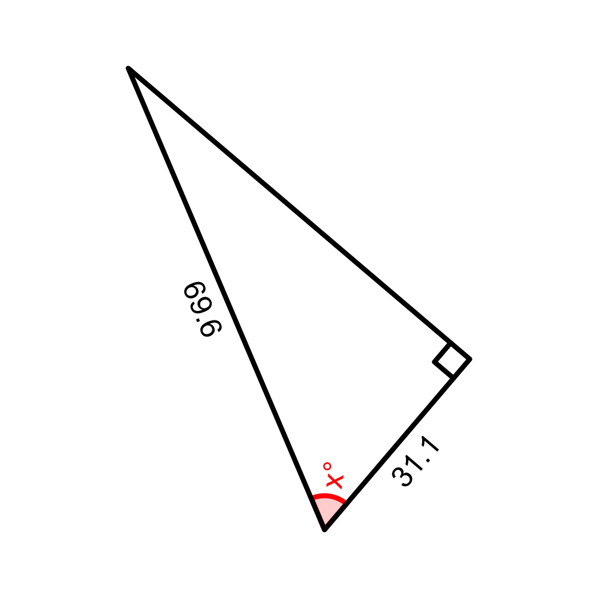

The tolerance is $\pm 0.1$.

Remember pythagorean theorem (for finding a side length from the other two side lengths).

$$(\text{adj})^2+(\text{opp})^2=(\text{hyp})^2$$

Remember SOH-CAH-TOA (for relating side-length ratios to angles).

$$\sin(\theta)=\frac{\text{opp}}{\text{hyp}}$$
$$\cos(\theta)=\frac{\text{adj}}{\text{hyp}}$$
$$\tan(\theta)=\frac{\text{opp}}{\text{adj}}$$

Use the appropriate equation.

$$\cos(x)=\frac{31.1}{69.6}$$
$$x=\arccos\left(\frac{31.1}{69.6}\right)$$

$$x=63.5$$

On the right triangle below, find the unknown length or angle (in degrees).

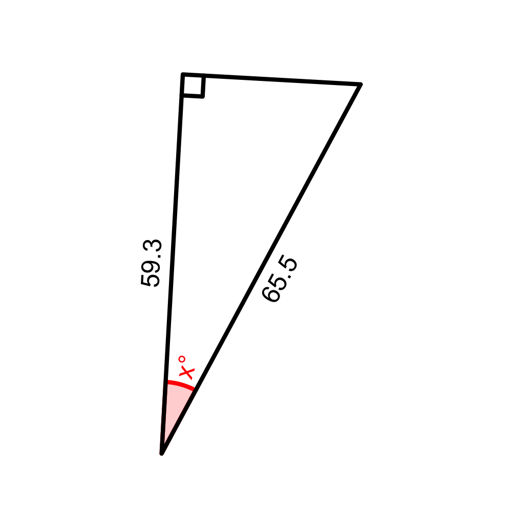

The tolerance is $\pm 0.1$.

Remember pythagorean theorem (for finding a side length from the other two side lengths).

$$(\text{adj})^2+(\text{opp})^2=(\text{hyp})^2$$

Remember SOH-CAH-TOA (for relating side-length ratios to angles).

$$\sin(\theta)=\frac{\text{opp}}{\text{hyp}}$$
$$\cos(\theta)=\frac{\text{adj}}{\text{hyp}}$$
$$\tan(\theta)=\frac{\text{opp}}{\text{adj}}$$

Use the appropriate equation.

$$\cos(x)=\frac{59.3}{65.5}$$
$$x=\arccos\left(\frac{59.3}{65.5}\right)$$

$$x=25.1$$

On the right triangle below, find the unknown length or angle (in degrees).

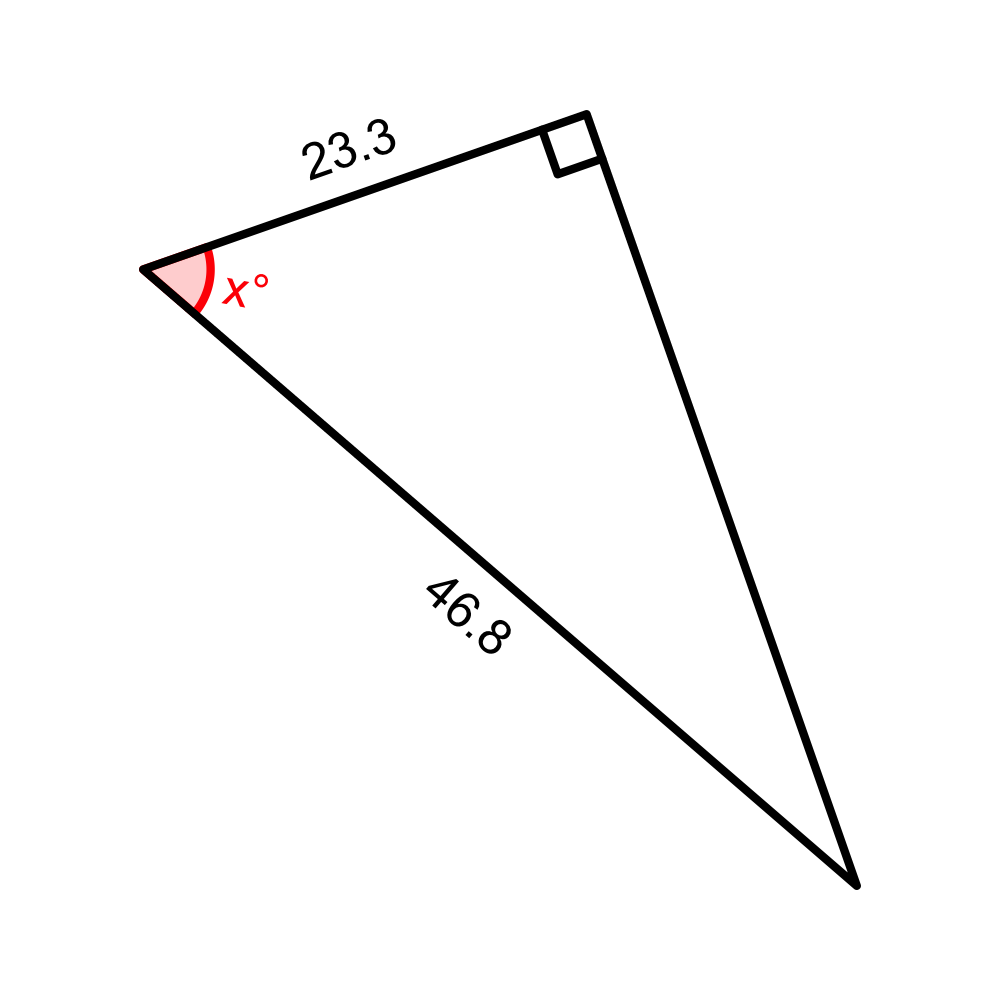

The tolerance is $\pm 0.1$.

Remember pythagorean theorem (for finding a side length from the other two side lengths).

$$(\text{adj})^2+(\text{opp})^2=(\text{hyp})^2$$

Remember SOH-CAH-TOA (for relating side-length ratios to angles).

$$\sin(\theta)=\frac{\text{opp}}{\text{hyp}}$$
$$\cos(\theta)=\frac{\text{adj}}{\text{hyp}}$$
$$\tan(\theta)=\frac{\text{opp}}{\text{adj}}$$

Use the appropriate equation.

$$\cos(x)=\frac{23.3}{46.8}$$
$$x=\arccos\left(\frac{23.3}{46.8}\right)$$

$$x=60.1$$

On the right triangle below, find the unknown length or angle (in degrees).

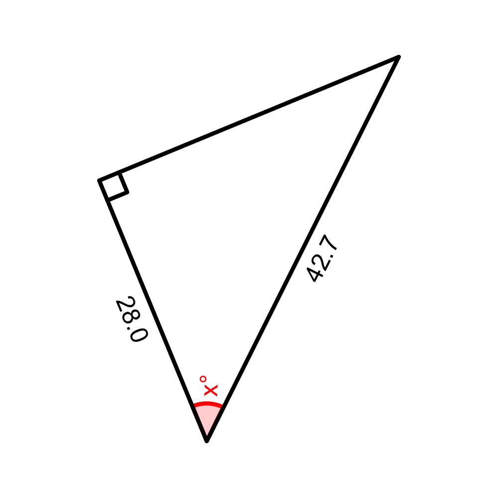

The tolerance is $\pm 0.1$.

Remember pythagorean theorem (for finding a side length from the other two side lengths).

$$(\text{adj})^2+(\text{opp})^2=(\text{hyp})^2$$

Remember SOH-CAH-TOA (for relating side-length ratios to angles).

$$\sin(\theta)=\frac{\text{opp}}{\text{hyp}}$$
$$\cos(\theta)=\frac{\text{adj}}{\text{hyp}}$$
$$\tan(\theta)=\frac{\text{opp}}{\text{adj}}$$

Use the appropriate equation.

$$\cos(x)=\frac{28}{42.7}$$
$$x=\arccos\left(\frac{28}{42.7}\right)$$

$$x=49$$

On the right triangle below, find the unknown length or angle (in degrees).

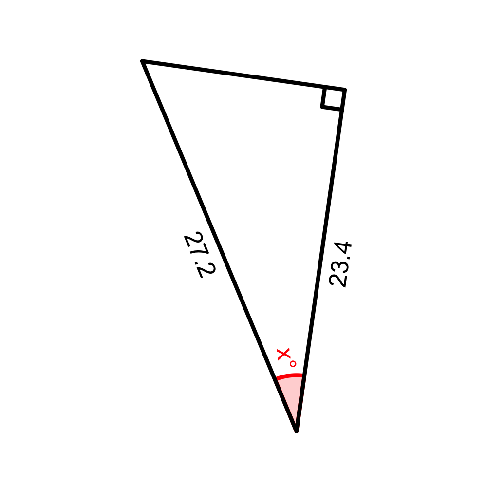

The tolerance is $\pm 0.1$.

Remember pythagorean theorem (for finding a side length from the other two side lengths).

$$(\text{adj})^2+(\text{opp})^2=(\text{hyp})^2$$

Remember SOH-CAH-TOA (for relating side-length ratios to angles).

$$\sin(\theta)=\frac{\text{opp}}{\text{hyp}}$$
$$\cos(\theta)=\frac{\text{adj}}{\text{hyp}}$$
$$\tan(\theta)=\frac{\text{opp}}{\text{adj}}$$

Use the appropriate equation.

$$\cos(x)=\frac{23.4}{27.2}$$
$$x=\arccos\left(\frac{23.4}{27.2}\right)$$

$$x=30.7$$

On the right triangle below, find the unknown length or angle (in degrees).

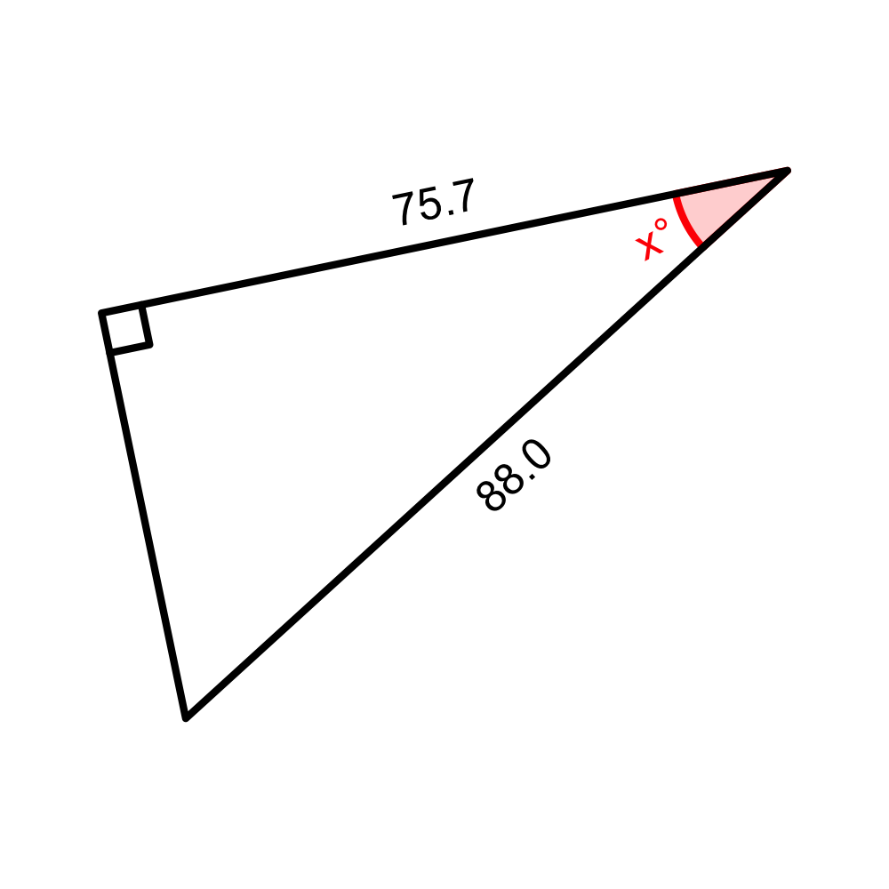

The tolerance is $\pm 0.1$.

Remember pythagorean theorem (for finding a side length from the other two side lengths).

$$(\text{adj})^2+(\text{opp})^2=(\text{hyp})^2$$

Remember SOH-CAH-TOA (for relating side-length ratios to angles).

$$\sin(\theta)=\frac{\text{opp}}{\text{hyp}}$$
$$\cos(\theta)=\frac{\text{adj}}{\text{hyp}}$$
$$\tan(\theta)=\frac{\text{opp}}{\text{adj}}$$

Use the appropriate equation.

$$\cos(x)=\frac{75.7}{88}$$
$$x=\arccos\left(\frac{75.7}{88}\right)$$

$$x=30.7$$

On the right triangle below, find the unknown length or angle (in degrees).

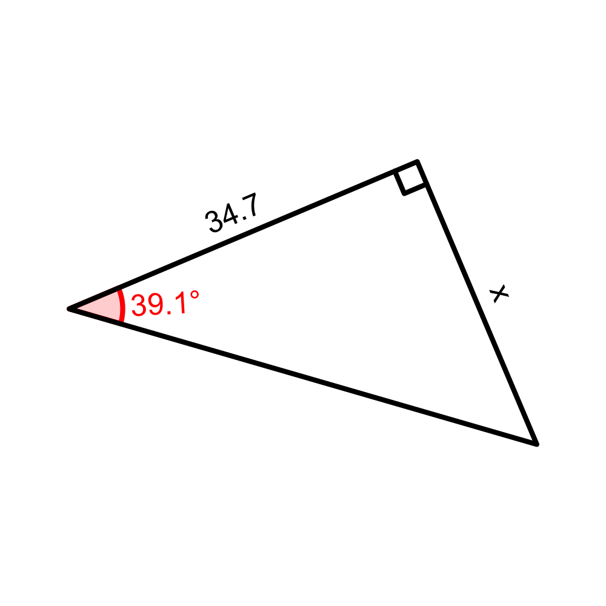

The tolerance is $\pm 0.1$.

Remember pythagorean theorem (for finding a side length from the other two side lengths).

$$(\text{adj})^2+(\text{opp})^2=(\text{hyp})^2$$

Remember SOH-CAH-TOA (for relating side-length ratios to angles).

$$\sin(\theta)=\frac{\text{opp}}{\text{hyp}}$$
$$\cos(\theta)=\frac{\text{adj}}{\text{hyp}}$$
$$\tan(\theta)=\frac{\text{opp}}{\text{adj}}$$

Use the appropriate equation.

$$\tan(39.1)=\frac{x}{34.7}$$
$$x=34.7\cdot\tan(39.1)$$

$$x=28.2$$

On the right triangle below, find the unknown length or angle (in degrees).

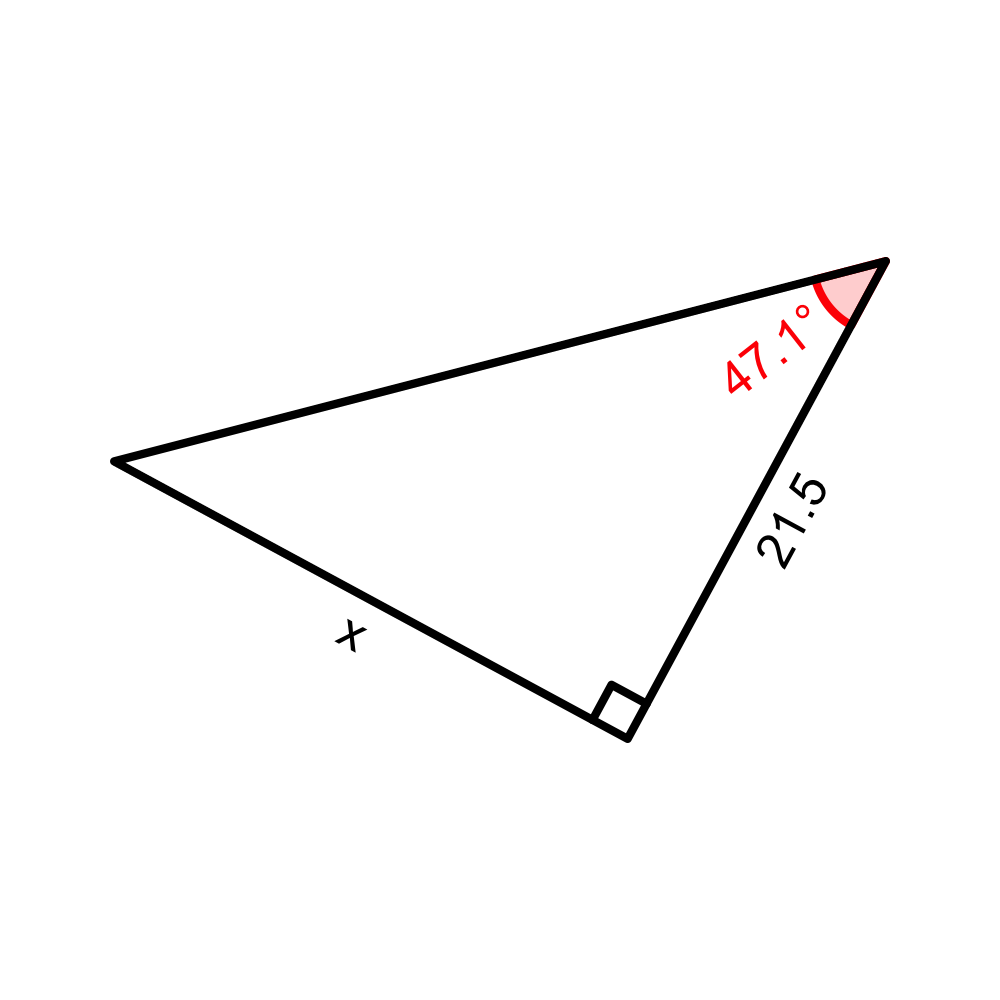

The tolerance is $\pm 0.1$.

Remember pythagorean theorem (for finding a side length from the other two side lengths).

$$(\text{adj})^2+(\text{opp})^2=(\text{hyp})^2$$

Remember SOH-CAH-TOA (for relating side-length ratios to angles).

$$\sin(\theta)=\frac{\text{opp}}{\text{hyp}}$$
$$\cos(\theta)=\frac{\text{adj}}{\text{hyp}}$$
$$\tan(\theta)=\frac{\text{opp}}{\text{adj}}$$

Use the appropriate equation.

$$\tan(47.1)=\frac{x}{21.5}$$
$$x=21.5\cdot\tan(47.1)$$

$$x=23.1$$

On the right triangle below, find the unknown length or angle (in degrees).

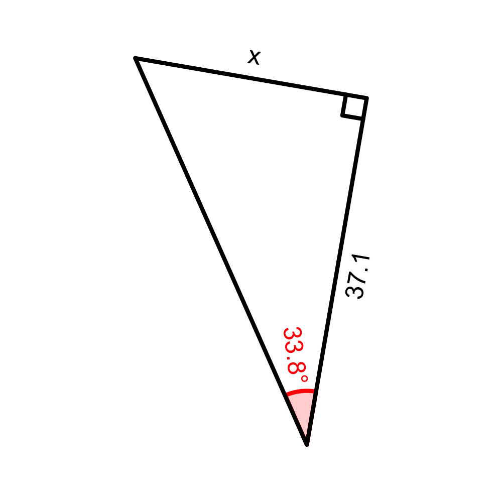

The tolerance is $\pm 0.1$.

Remember pythagorean theorem (for finding a side length from the other two side lengths).

$$(\text{adj})^2+(\text{opp})^2=(\text{hyp})^2$$

Remember SOH-CAH-TOA (for relating side-length ratios to angles).

$$\sin(\theta)=\frac{\text{opp}}{\text{hyp}}$$
$$\cos(\theta)=\frac{\text{adj}}{\text{hyp}}$$
$$\tan(\theta)=\frac{\text{opp}}{\text{adj}}$$

Use the appropriate equation.

$$\tan(33.8)=\frac{x}{37.1}$$
$$x=37.1\cdot\tan(33.8)$$

$$x=24.8$$

On the right triangle below, find the unknown length or angle (in degrees).

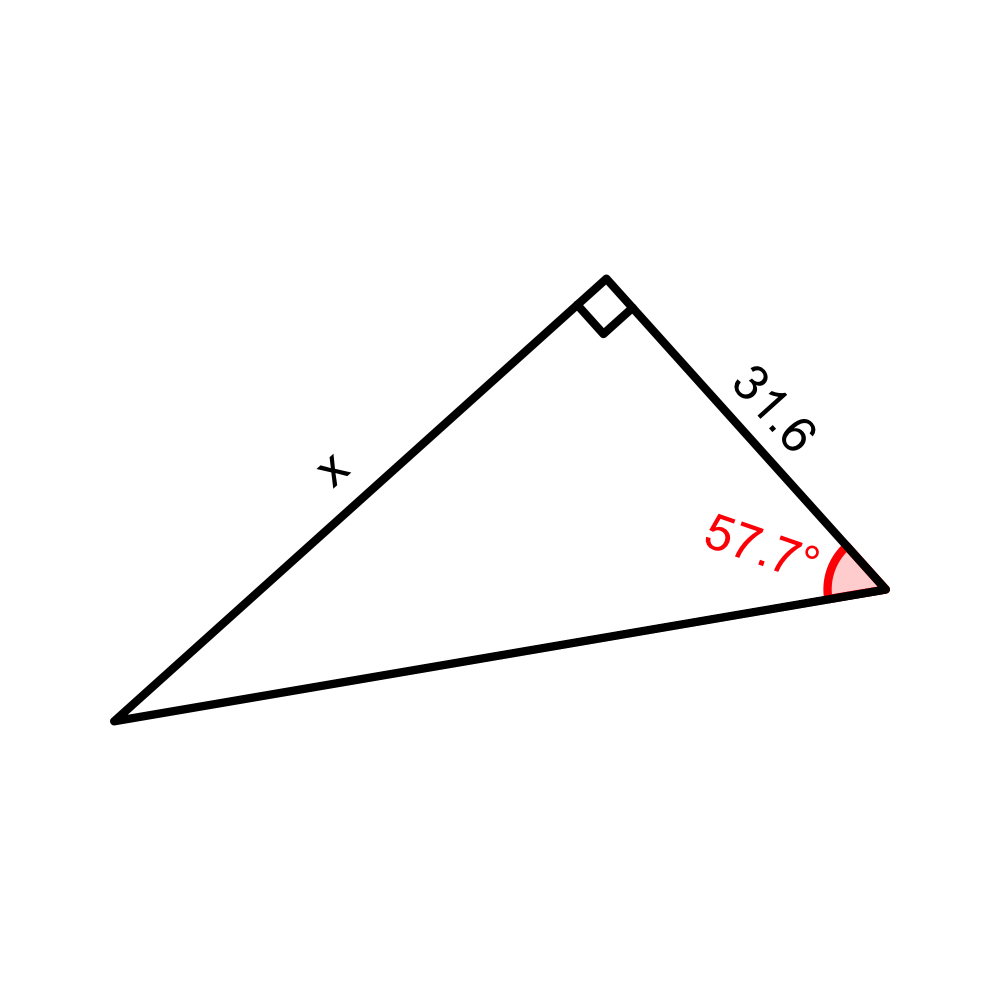

The tolerance is $\pm 0.1$.

Remember pythagorean theorem (for finding a side length from the other two side lengths).

$$(\text{adj})^2+(\text{opp})^2=(\text{hyp})^2$$

Remember SOH-CAH-TOA (for relating side-length ratios to angles).

$$\sin(\theta)=\frac{\text{opp}}{\text{hyp}}$$
$$\cos(\theta)=\frac{\text{adj}}{\text{hyp}}$$
$$\tan(\theta)=\frac{\text{opp}}{\text{adj}}$$

Use the appropriate equation.

$$\tan(57.7)=\frac{x}{31.6}$$
$$x=31.6\cdot\tan(57.7)$$

$$x=50$$

On the right triangle below, find the unknown length or angle (in degrees).

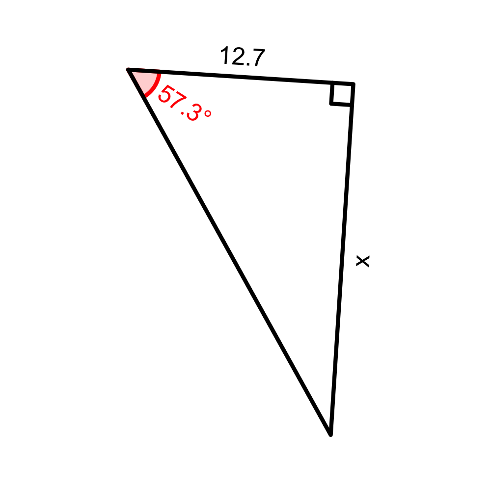

The tolerance is $\pm 0.1$.

Remember pythagorean theorem (for finding a side length from the other two side lengths).

$$(\text{adj})^2+(\text{opp})^2=(\text{hyp})^2$$

Remember SOH-CAH-TOA (for relating side-length ratios to angles).

$$\sin(\theta)=\frac{\text{opp}}{\text{hyp}}$$
$$\cos(\theta)=\frac{\text{adj}}{\text{hyp}}$$
$$\tan(\theta)=\frac{\text{opp}}{\text{adj}}$$

Use the appropriate equation.

$$\tan(57.3)=\frac{x}{12.7}$$
$$x=12.7\cdot\tan(57.3)$$

$$x=19.8$$

On the right triangle below, find the unknown length or angle (in degrees).

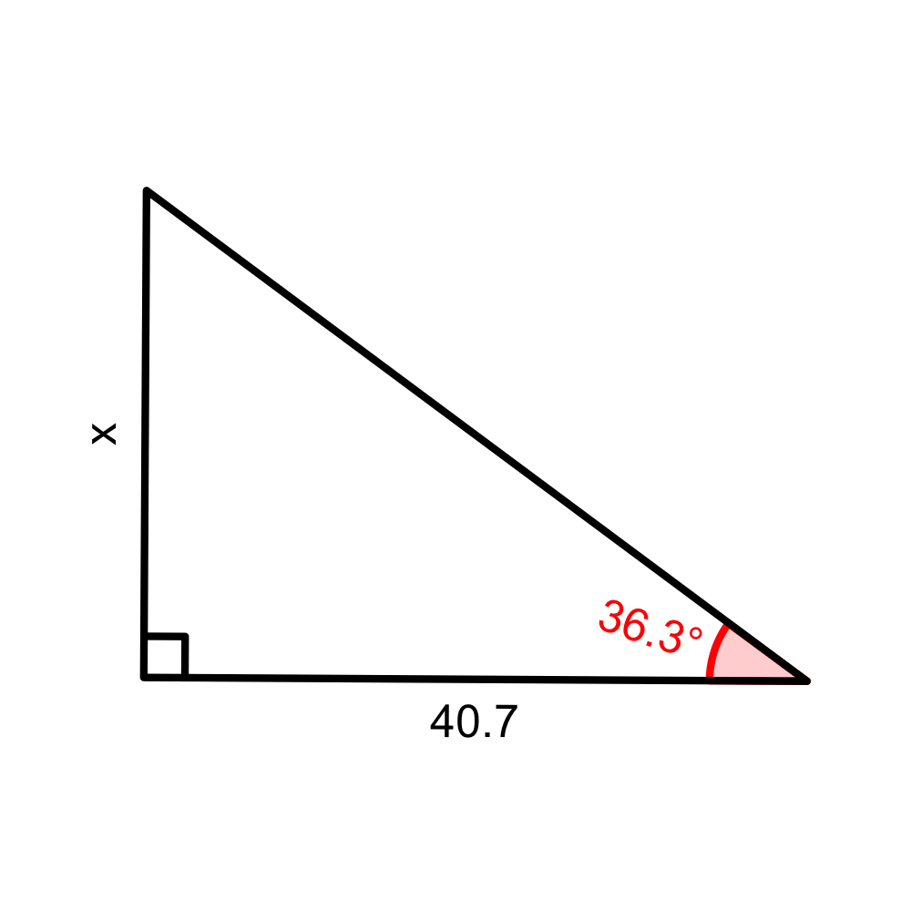

The tolerance is $\pm 0.1$.

Remember pythagorean theorem (for finding a side length from the other two side lengths).

$$(\text{adj})^2+(\text{opp})^2=(\text{hyp})^2$$

Remember SOH-CAH-TOA (for relating side-length ratios to angles).

$$\sin(\theta)=\frac{\text{opp}}{\text{hyp}}$$
$$\cos(\theta)=\frac{\text{adj}}{\text{hyp}}$$
$$\tan(\theta)=\frac{\text{opp}}{\text{adj}}$$

Use the appropriate equation.

$$\tan(36.3)=\frac{x}{40.7}$$
$$x=40.7\cdot\tan(36.3)$$

$$x=29.9$$

On the right triangle below, find the unknown length or angle (in degrees).

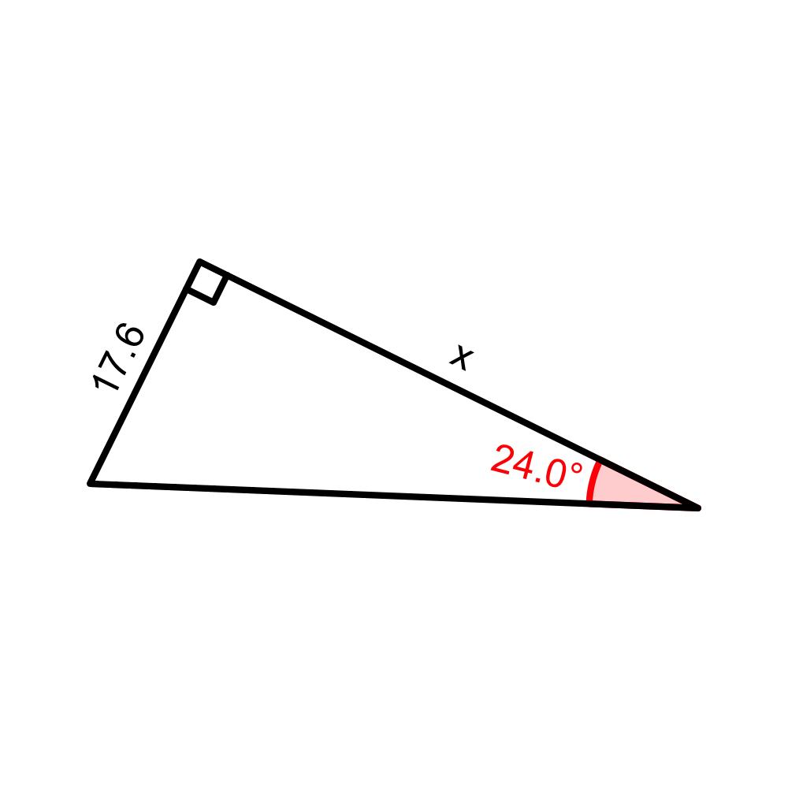

The tolerance is $\pm 0.1$.

Remember pythagorean theorem (for finding a side length from the other two side lengths).

$$(\text{adj})^2+(\text{opp})^2=(\text{hyp})^2$$

Remember SOH-CAH-TOA (for relating side-length ratios to angles).

$$\sin(\theta)=\frac{\text{opp}}{\text{hyp}}$$
$$\cos(\theta)=\frac{\text{adj}}{\text{hyp}}$$
$$\tan(\theta)=\frac{\text{opp}}{\text{adj}}$$

Use the appropriate equation.

$$\tan(24)=\frac{17.6}{x}$$
$$x=\frac{17.6}{\tan(24)}$$

$$x=39.5$$

On the right triangle below, find the unknown length or angle (in degrees).

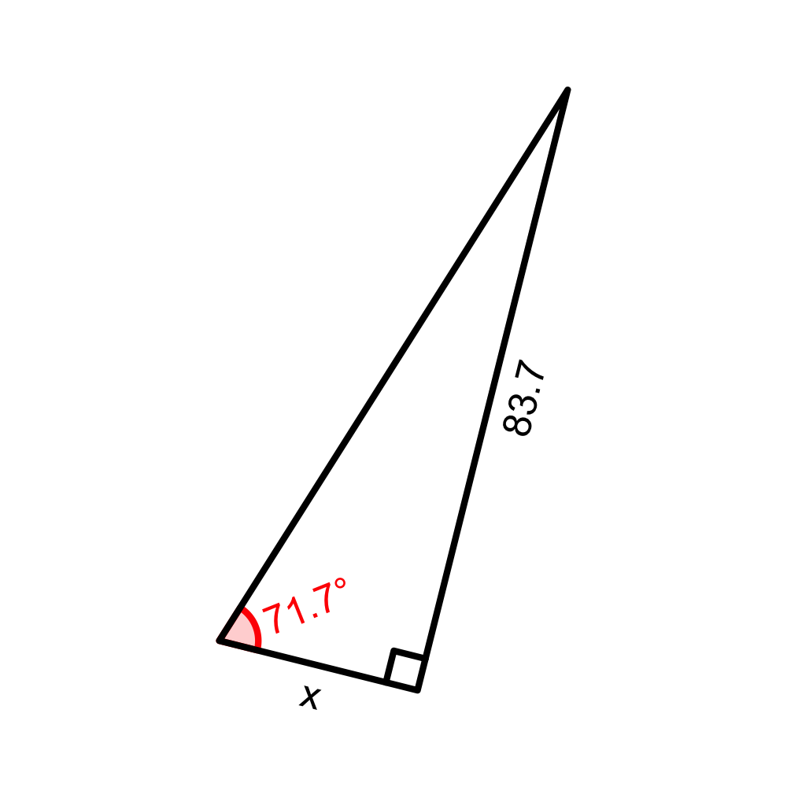

The tolerance is $\pm 0.1$.

Remember pythagorean theorem (for finding a side length from the other two side lengths).

$$(\text{adj})^2+(\text{opp})^2=(\text{hyp})^2$$

Remember SOH-CAH-TOA (for relating side-length ratios to angles).

$$\sin(\theta)=\frac{\text{opp}}{\text{hyp}}$$
$$\cos(\theta)=\frac{\text{adj}}{\text{hyp}}$$
$$\tan(\theta)=\frac{\text{opp}}{\text{adj}}$$

Use the appropriate equation.

$$\tan(71.7)=\frac{83.7}{x}$$
$$x=\frac{83.7}{\tan(71.7)}$$

$$x=27.7$$

On the right triangle below, find the unknown length or angle (in degrees).

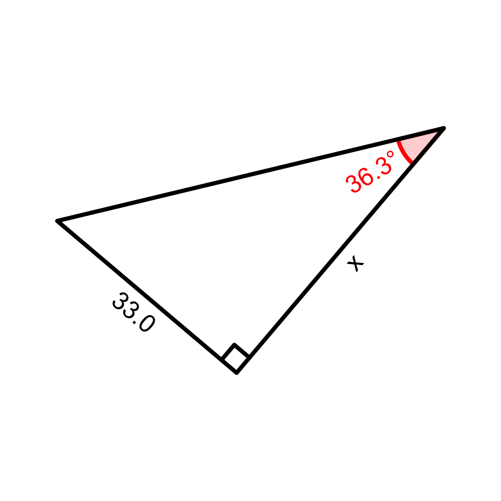

The tolerance is $\pm 0.1$.

Remember pythagorean theorem (for finding a side length from the other two side lengths).

$$(\text{adj})^2+(\text{opp})^2=(\text{hyp})^2$$

Remember SOH-CAH-TOA (for relating side-length ratios to angles).

$$\sin(\theta)=\frac{\text{opp}}{\text{hyp}}$$
$$\cos(\theta)=\frac{\text{adj}}{\text{hyp}}$$
$$\tan(\theta)=\frac{\text{opp}}{\text{adj}}$$

Use the appropriate equation.

$$\tan(36.3)=\frac{33}{x}$$
$$x=\frac{33}{\tan(36.3)}$$

$$x=44.9$$

On the right triangle below, find the unknown length or angle (in degrees).

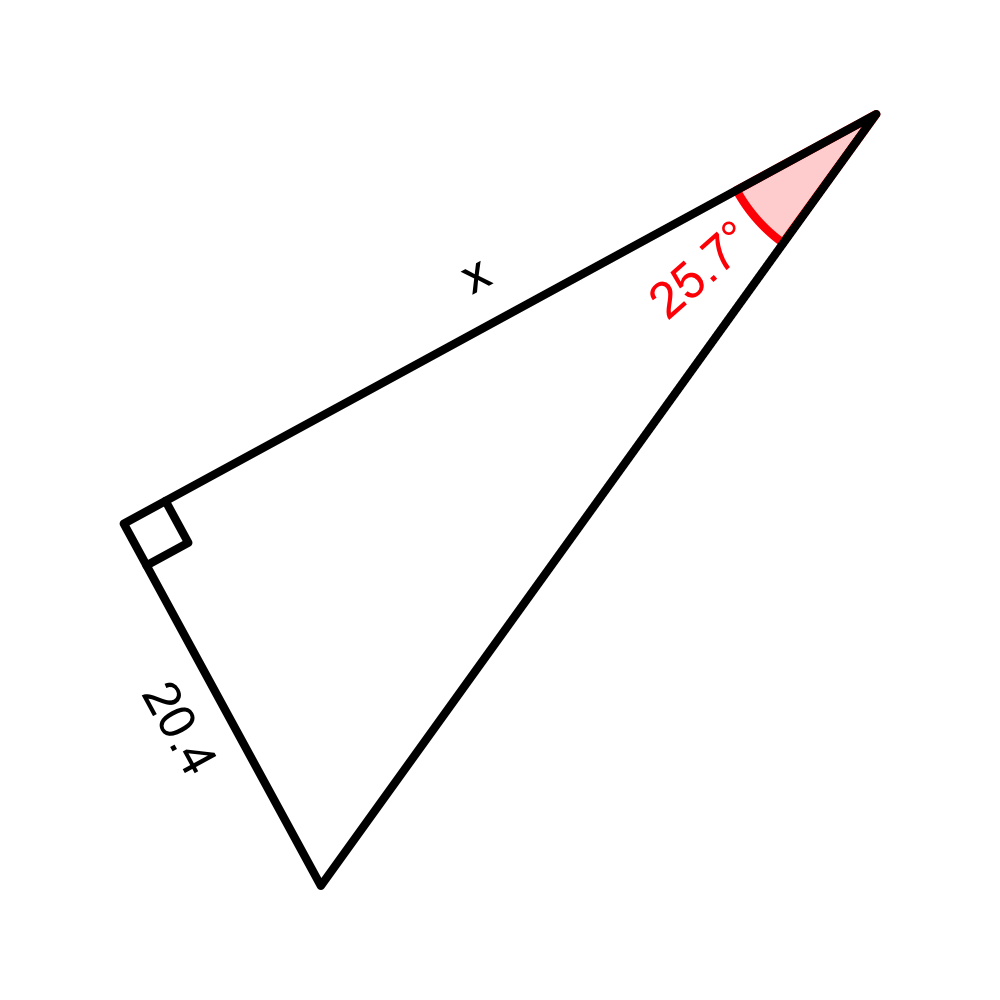

The tolerance is $\pm 0.1$.

Remember pythagorean theorem (for finding a side length from the other two side lengths).

$$(\text{adj})^2+(\text{opp})^2=(\text{hyp})^2$$

Remember SOH-CAH-TOA (for relating side-length ratios to angles).

$$\sin(\theta)=\frac{\text{opp}}{\text{hyp}}$$
$$\cos(\theta)=\frac{\text{adj}}{\text{hyp}}$$
$$\tan(\theta)=\frac{\text{opp}}{\text{adj}}$$

Use the appropriate equation.

$$\tan(25.7)=\frac{20.4}{x}$$
$$x=\frac{20.4}{\tan(25.7)}$$

$$x=42.4$$

On the right triangle below, find the unknown length or angle (in degrees).

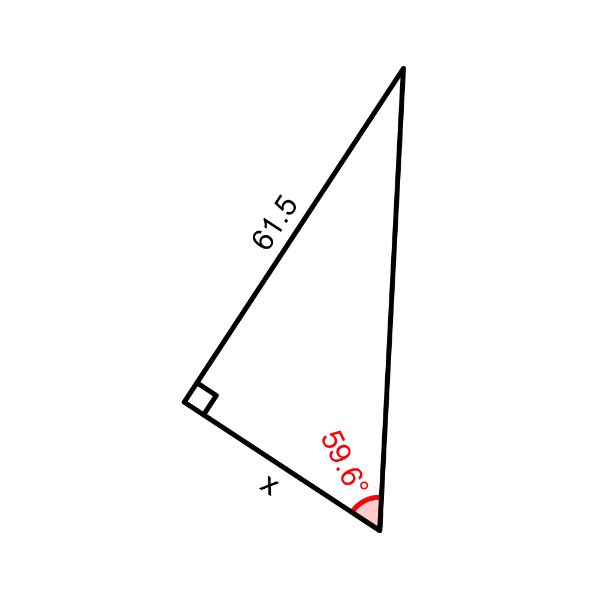

The tolerance is $\pm 0.1$.

Remember pythagorean theorem (for finding a side length from the other two side lengths).

$$(\text{adj})^2+(\text{opp})^2=(\text{hyp})^2$$

Remember SOH-CAH-TOA (for relating side-length ratios to angles).

$$\sin(\theta)=\frac{\text{opp}}{\text{hyp}}$$
$$\cos(\theta)=\frac{\text{adj}}{\text{hyp}}$$
$$\tan(\theta)=\frac{\text{opp}}{\text{adj}}$$

Use the appropriate equation.

$$\tan(59.6)=\frac{61.5}{x}$$
$$x=\frac{61.5}{\tan(59.6)}$$

$$x=36.1$$

On the right triangle below, find the unknown length or angle (in degrees).

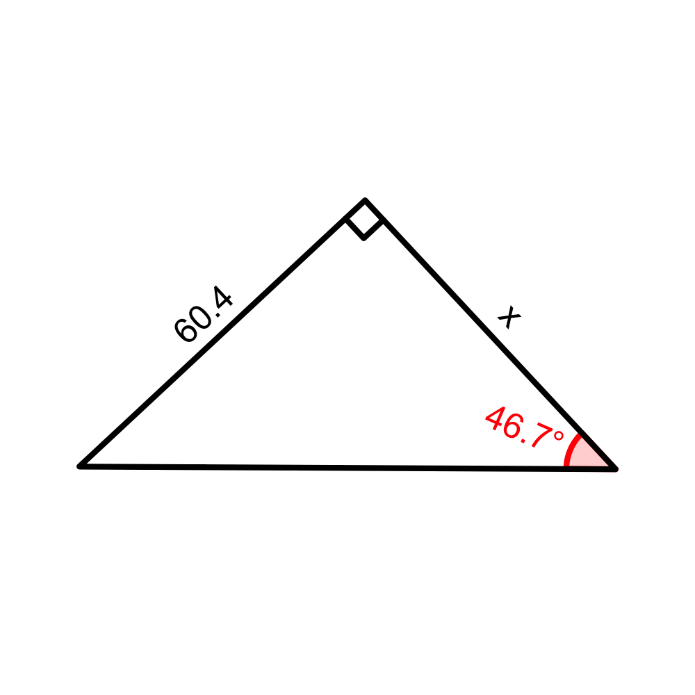

The tolerance is $\pm 0.1$.

Remember pythagorean theorem (for finding a side length from the other two side lengths).

$$(\text{adj})^2+(\text{opp})^2=(\text{hyp})^2$$

Remember SOH-CAH-TOA (for relating side-length ratios to angles).

$$\sin(\theta)=\frac{\text{opp}}{\text{hyp}}$$
$$\cos(\theta)=\frac{\text{adj}}{\text{hyp}}$$
$$\tan(\theta)=\frac{\text{opp}}{\text{adj}}$$

Use the appropriate equation.

$$\tan(46.7)=\frac{60.4}{x}$$
$$x=\frac{60.4}{\tan(46.7)}$$

$$x=56.9$$

On the right triangle below, find the unknown length or angle (in degrees).

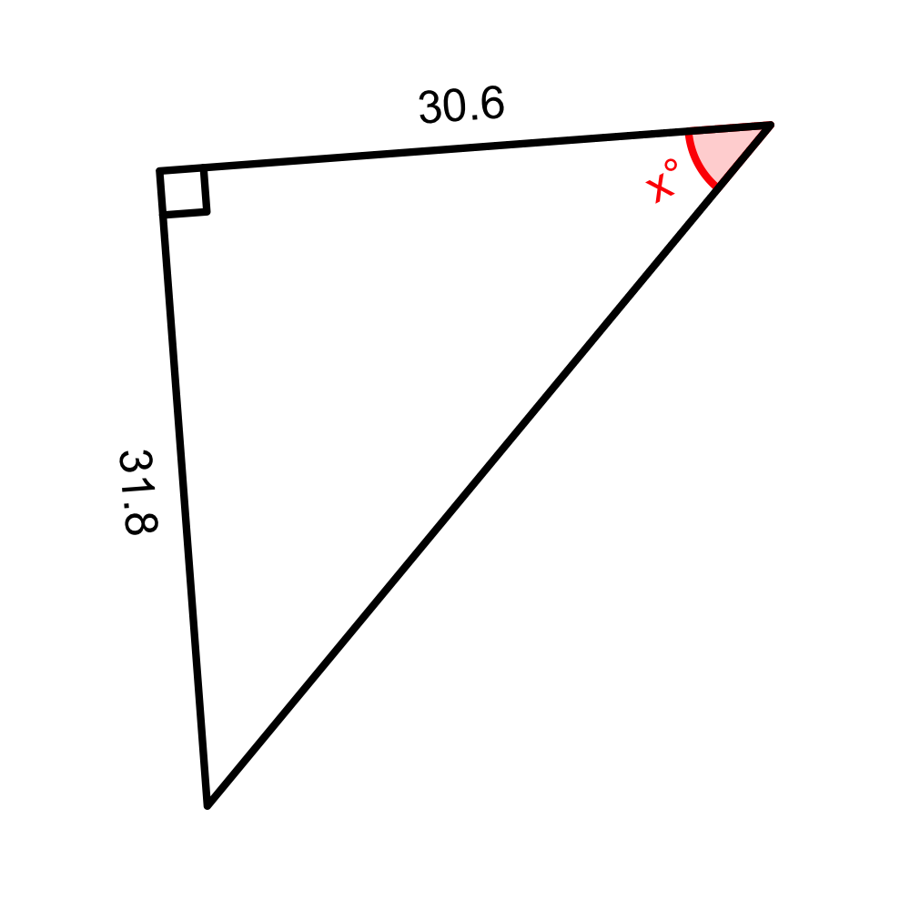

The tolerance is $\pm 0.1$.

Remember pythagorean theorem (for finding a side length from the other two side lengths).

$$(\text{adj})^2+(\text{opp})^2=(\text{hyp})^2$$

Remember SOH-CAH-TOA (for relating side-length ratios to angles).

$$\sin(\theta)=\frac{\text{opp}}{\text{hyp}}$$
$$\cos(\theta)=\frac{\text{adj}}{\text{hyp}}$$
$$\tan(\theta)=\frac{\text{opp}}{\text{adj}}$$

Use the appropriate equation.

$$\tan(x)=\frac{31.8}{30.6}$$
$$x=\arctan\left(\frac{31.8}{30.6}\right)$$

$$x=46.1$$

On the right triangle below, find the unknown length or angle (in degrees).

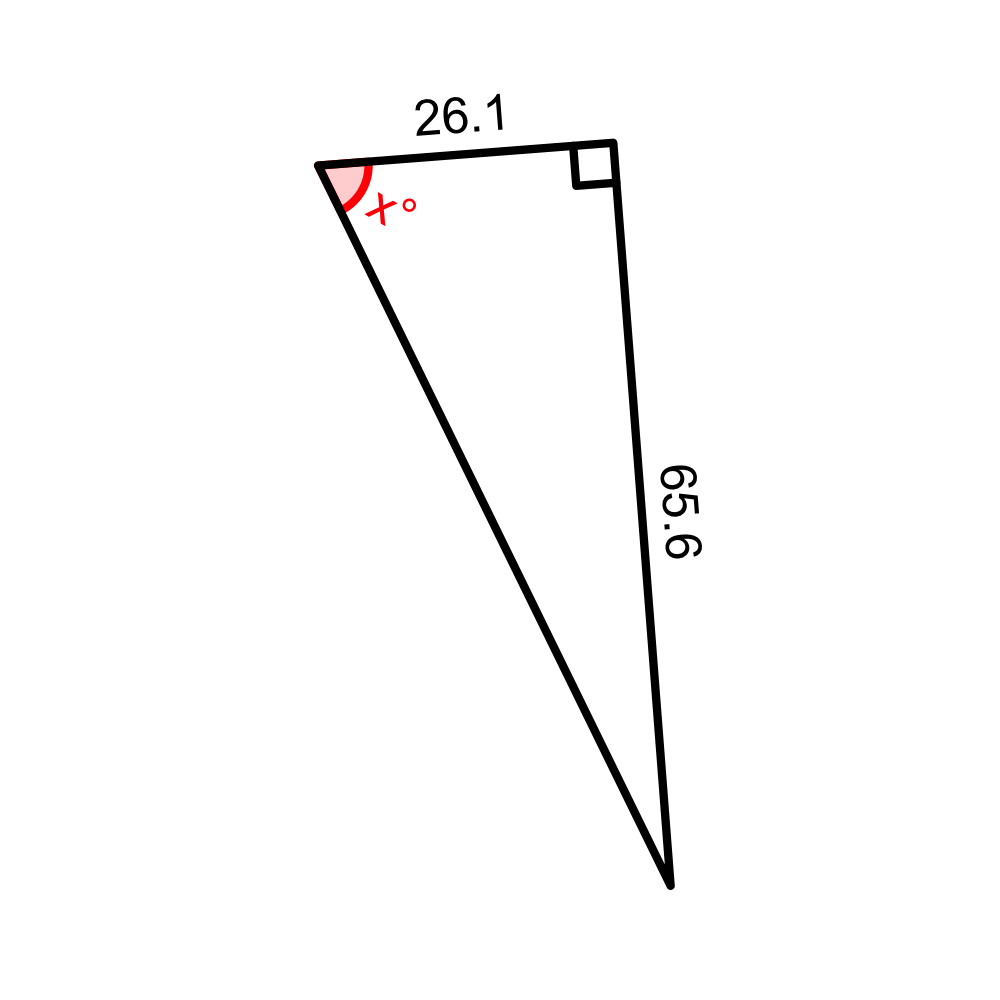

The tolerance is $\pm 0.1$.

Remember pythagorean theorem (for finding a side length from the other two side lengths).

$$(\text{adj})^2+(\text{opp})^2=(\text{hyp})^2$$

Remember SOH-CAH-TOA (for relating side-length ratios to angles).

$$\sin(\theta)=\frac{\text{opp}}{\text{hyp}}$$
$$\cos(\theta)=\frac{\text{adj}}{\text{hyp}}$$
$$\tan(\theta)=\frac{\text{opp}}{\text{adj}}$$

Use the appropriate equation.

$$\tan(x)=\frac{65.6}{26.1}$$
$$x=\arctan\left(\frac{65.6}{26.1}\right)$$

$$x=68.3$$

On the right triangle below, find the unknown length or angle (in degrees).

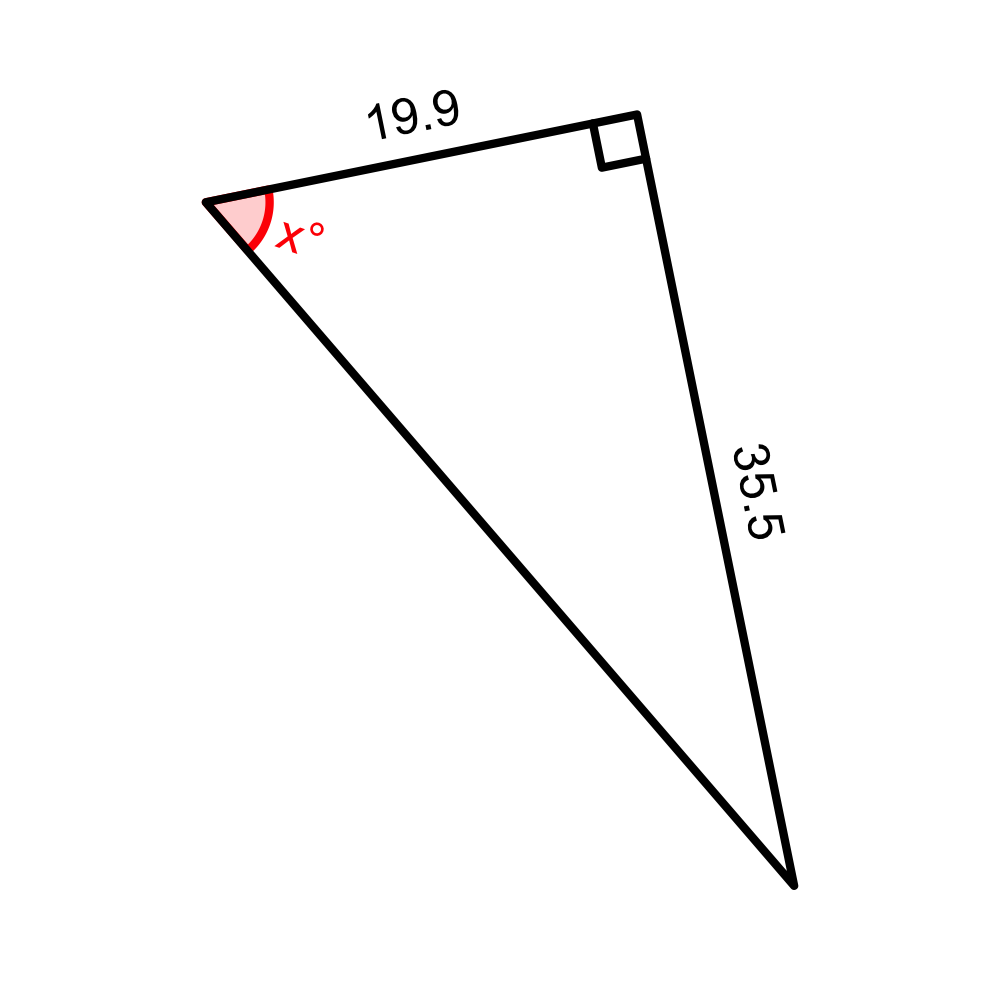

The tolerance is $\pm 0.1$.

Remember pythagorean theorem (for finding a side length from the other two side lengths).

$$(\text{adj})^2+(\text{opp})^2=(\text{hyp})^2$$

Remember SOH-CAH-TOA (for relating side-length ratios to angles).

$$\sin(\theta)=\frac{\text{opp}}{\text{hyp}}$$
$$\cos(\theta)=\frac{\text{adj}}{\text{hyp}}$$
$$\tan(\theta)=\frac{\text{opp}}{\text{adj}}$$

Use the appropriate equation.

$$\tan(x)=\frac{35.5}{19.9}$$
$$x=\arctan\left(\frac{35.5}{19.9}\right)$$

$$x=60.7$$

On the right triangle below, find the unknown length or angle (in degrees).

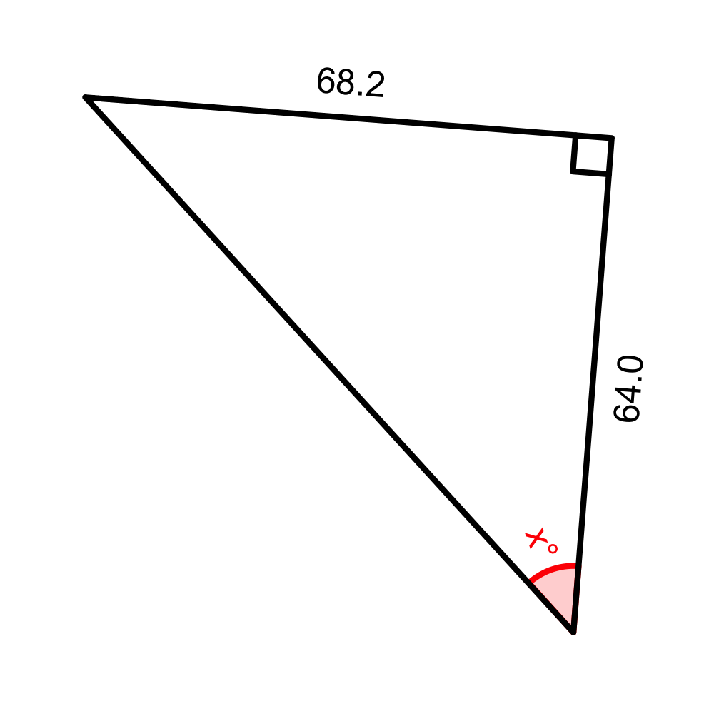

The tolerance is $\pm 0.1$.

Remember pythagorean theorem (for finding a side length from the other two side lengths).

$$(\text{adj})^2+(\text{opp})^2=(\text{hyp})^2$$

Remember SOH-CAH-TOA (for relating side-length ratios to angles).

$$\sin(\theta)=\frac{\text{opp}}{\text{hyp}}$$
$$\cos(\theta)=\frac{\text{adj}}{\text{hyp}}$$
$$\tan(\theta)=\frac{\text{opp}}{\text{adj}}$$

Use the appropriate equation.

$$\tan(x)=\frac{68.2}{64}$$
$$x=\arctan\left(\frac{68.2}{64}\right)$$

$$x=46.8$$

On the right triangle below, find the unknown length or angle (in degrees).

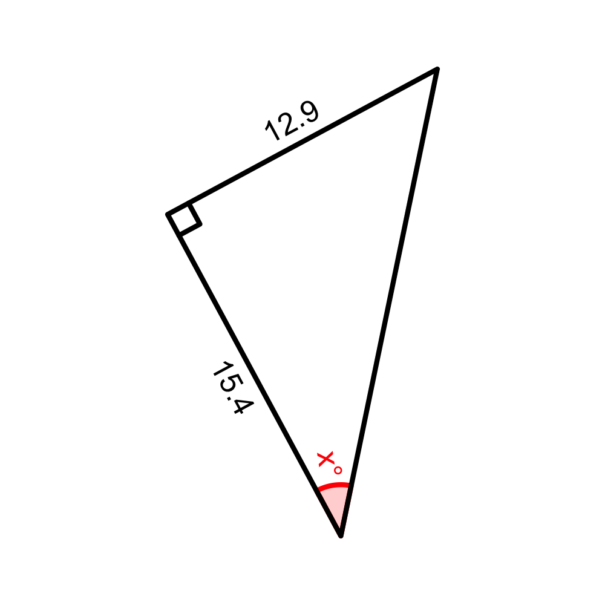

The tolerance is $\pm 0.1$.

Remember pythagorean theorem (for finding a side length from the other two side lengths).

$$(\text{adj})^2+(\text{opp})^2=(\text{hyp})^2$$

Remember SOH-CAH-TOA (for relating side-length ratios to angles).

$$\sin(\theta)=\frac{\text{opp}}{\text{hyp}}$$
$$\cos(\theta)=\frac{\text{adj}}{\text{hyp}}$$
$$\tan(\theta)=\frac{\text{opp}}{\text{adj}}$$

Use the appropriate equation.

$$\tan(x)=\frac{12.9}{15.4}$$
$$x=\arctan\left(\frac{12.9}{15.4}\right)$$

$$x=40$$

On the right triangle below, find the unknown length or angle (in degrees).

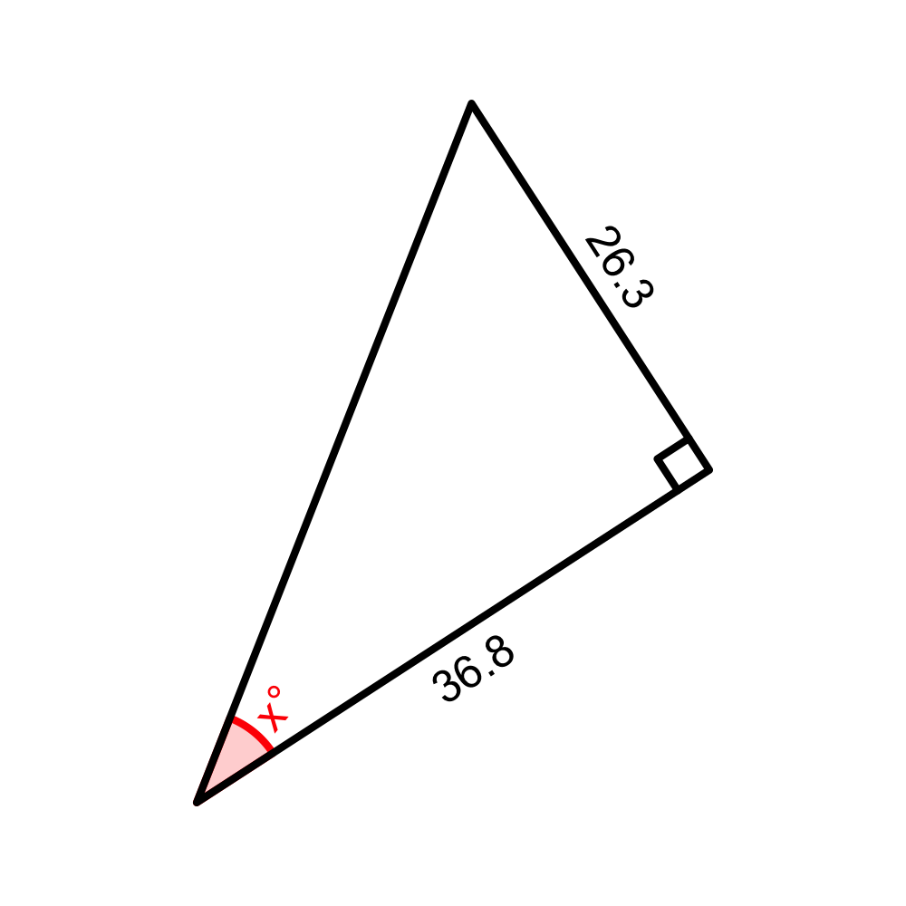

The tolerance is $\pm 0.1$.

Remember pythagorean theorem (for finding a side length from the other two side lengths).

$$(\text{adj})^2+(\text{opp})^2=(\text{hyp})^2$$

Remember SOH-CAH-TOA (for relating side-length ratios to angles).

$$\sin(\theta)=\frac{\text{opp}}{\text{hyp}}$$
$$\cos(\theta)=\frac{\text{adj}}{\text{hyp}}$$
$$\tan(\theta)=\frac{\text{opp}}{\text{adj}}$$

Use the appropriate equation.

$$\tan(x)=\frac{26.3}{36.8}$$
$$x=\arctan\left(\frac{26.3}{36.8}\right)$$

$$x=35.6$$

On the right triangle below, find the unknown length or angle (in degrees).

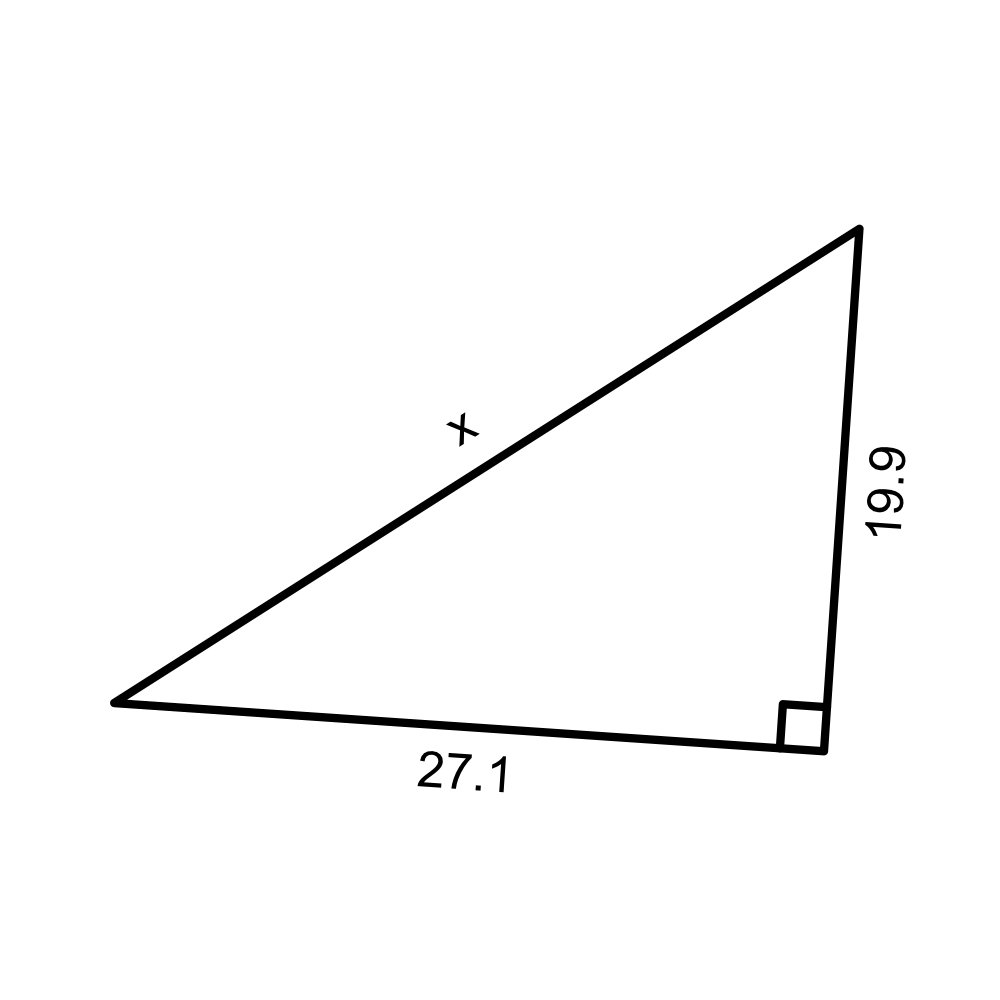

The tolerance is $\pm 0.1$.

Remember pythagorean theorem (for finding a side length from the other two side lengths).

$$(\text{adj})^2+(\text{opp})^2=(\text{hyp})^2$$

Remember SOH-CAH-TOA (for relating side-length ratios to angles).

$$\sin(\theta)=\frac{\text{opp}}{\text{hyp}}$$
$$\cos(\theta)=\frac{\text{adj}}{\text{hyp}}$$
$$\tan(\theta)=\frac{\text{opp}}{\text{adj}}$$

Use the appropriate equation.

$$27.1^2+19.9^2=x^2$$
$$x=\sqrt{734.41+396.01}$$

$$x=33.6$$

On the right triangle below, find the unknown length or angle (in degrees).

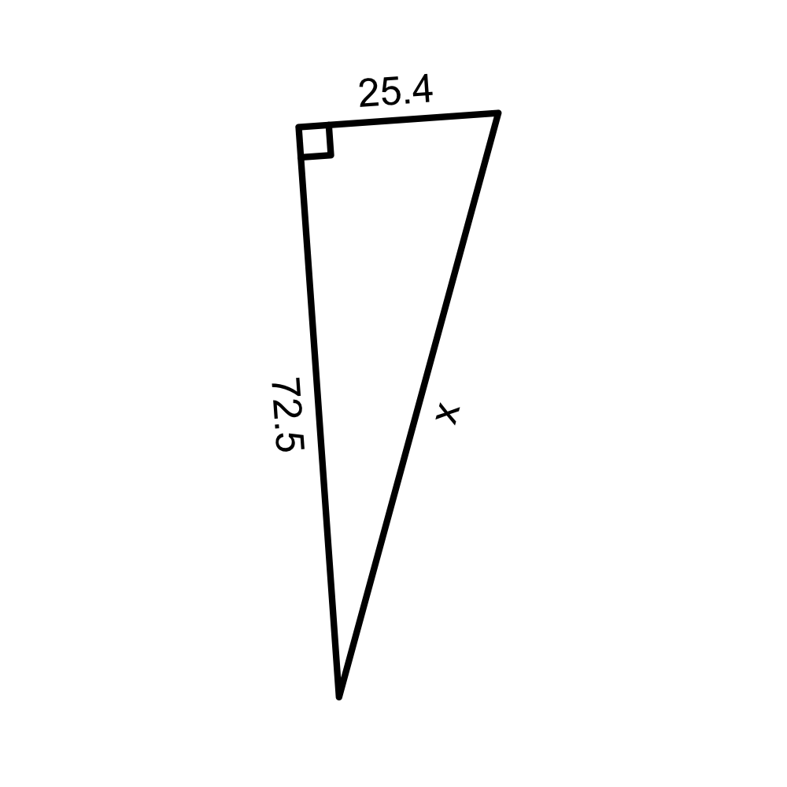

The tolerance is $\pm 0.1$.

Remember pythagorean theorem (for finding a side length from the other two side lengths).

$$(\text{adj})^2+(\text{opp})^2=(\text{hyp})^2$$

Remember SOH-CAH-TOA (for relating side-length ratios to angles).

$$\sin(\theta)=\frac{\text{opp}}{\text{hyp}}$$
$$\cos(\theta)=\frac{\text{adj}}{\text{hyp}}$$
$$\tan(\theta)=\frac{\text{opp}}{\text{adj}}$$

Use the appropriate equation.

$$25.4^2+72.5^2=x^2$$
$$x=\sqrt{645.16+5256.25}$$

$$x=76.8$$

On the right triangle below, find the unknown length or angle (in degrees).

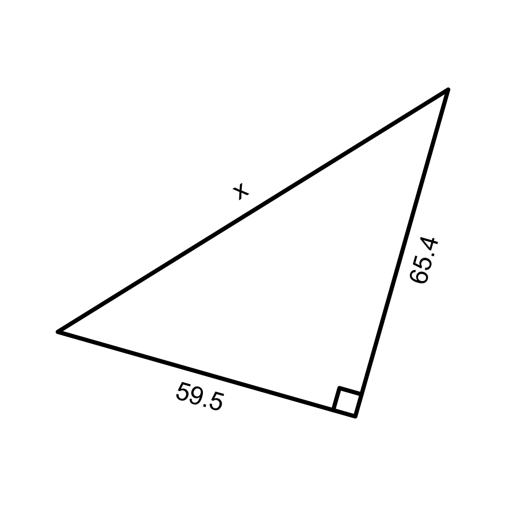

The tolerance is $\pm 0.1$.

Remember pythagorean theorem (for finding a side length from the other two side lengths).

$$(\text{adj})^2+(\text{opp})^2=(\text{hyp})^2$$

Remember SOH-CAH-TOA (for relating side-length ratios to angles).

$$\sin(\theta)=\frac{\text{opp}}{\text{hyp}}$$
$$\cos(\theta)=\frac{\text{adj}}{\text{hyp}}$$
$$\tan(\theta)=\frac{\text{opp}}{\text{adj}}$$

Use the appropriate equation.

$$59.5^2+65.4^2=x^2$$
$$x=\sqrt{3540.25+4277.16}$$

$$x=88.4$$

On the right triangle below, find the unknown length or angle (in degrees).

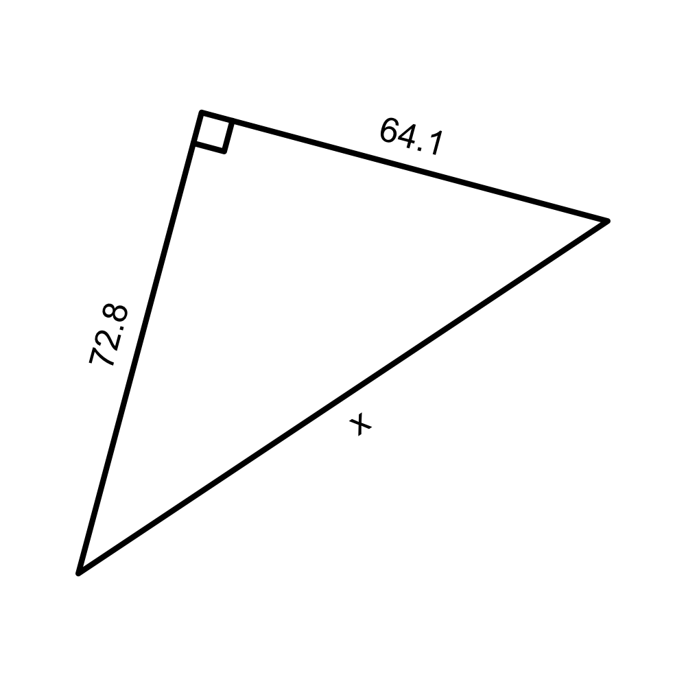

The tolerance is $\pm 0.1$.

Remember pythagorean theorem (for finding a side length from the other two side lengths).

$$(\text{adj})^2+(\text{opp})^2=(\text{hyp})^2$$

Remember SOH-CAH-TOA (for relating side-length ratios to angles).

$$\sin(\theta)=\frac{\text{opp}}{\text{hyp}}$$
$$\cos(\theta)=\frac{\text{adj}}{\text{hyp}}$$
$$\tan(\theta)=\frac{\text{opp}}{\text{adj}}$$

Use the appropriate equation.

$$64.1^2+72.8^2=x^2$$
$$x=\sqrt{4108.81+5299.84}$$

$$x=97$$

On the right triangle below, find the unknown length or angle (in degrees).

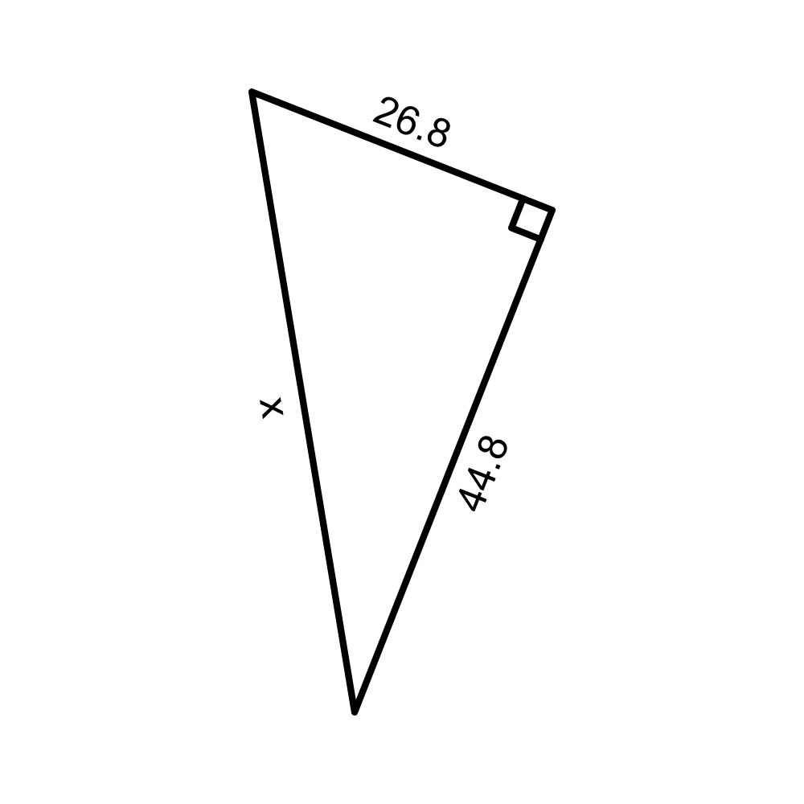

The tolerance is $\pm 0.1$.

Remember pythagorean theorem (for finding a side length from the other two side lengths).

$$(\text{adj})^2+(\text{opp})^2=(\text{hyp})^2$$

Remember SOH-CAH-TOA (for relating side-length ratios to angles).

$$\sin(\theta)=\frac{\text{opp}}{\text{hyp}}$$
$$\cos(\theta)=\frac{\text{adj}}{\text{hyp}}$$
$$\tan(\theta)=\frac{\text{opp}}{\text{adj}}$$

Use the appropriate equation.

$$44.8^2+26.8^2=x^2$$
$$x=\sqrt{2007.04+718.24}$$

$$x=52.2$$

On the right triangle below, find the unknown length or angle (in degrees).

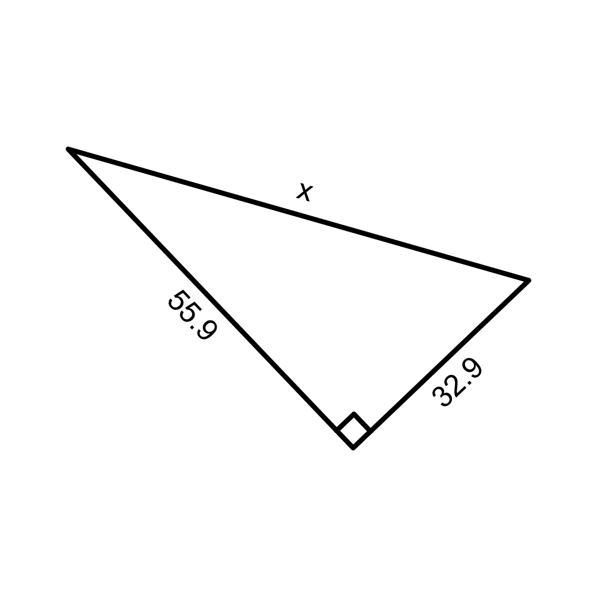

The tolerance is $\pm 0.1$.

Remember pythagorean theorem (for finding a side length from the other two side lengths).

$$(\text{adj})^2+(\text{opp})^2=(\text{hyp})^2$$

Remember SOH-CAH-TOA (for relating side-length ratios to angles).

$$\sin(\theta)=\frac{\text{opp}}{\text{hyp}}$$
$$\cos(\theta)=\frac{\text{adj}}{\text{hyp}}$$
$$\tan(\theta)=\frac{\text{opp}}{\text{adj}}$$

Use the appropriate equation.

$$32.9^2+55.9^2=x^2$$
$$x=\sqrt{1082.41+3124.81}$$

$$x=64.9$$

On the right triangle below, find the unknown length or angle (in degrees).

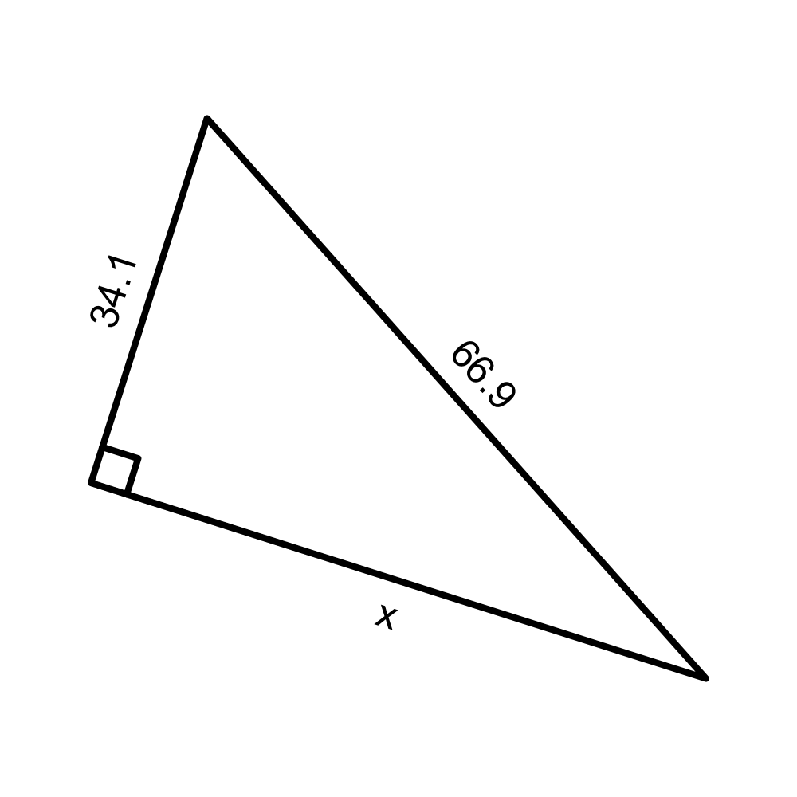

The tolerance is $\pm 0.1$.

Remember pythagorean theorem (for finding a side length from the other two side lengths).

$$(\text{adj})^2+(\text{opp})^2=(\text{hyp})^2$$

Remember SOH-CAH-TOA (for relating side-length ratios to angles).

$$\sin(\theta)=\frac{\text{opp}}{\text{hyp}}$$
$$\cos(\theta)=\frac{\text{adj}}{\text{hyp}}$$
$$\tan(\theta)=\frac{\text{opp}}{\text{adj}}$$

Use the appropriate equation.

$$34.1^2+x^2=66.9^2$$
$$x=\sqrt{4475.61-1162.81}$$

$$x=57.6$$

On the right triangle below, find the unknown length or angle (in degrees).

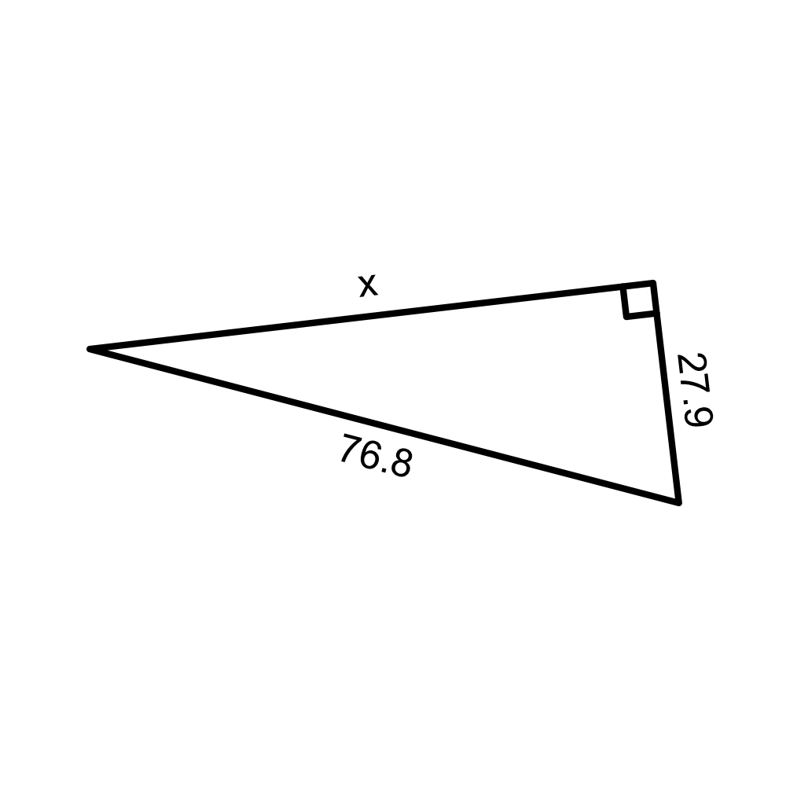

The tolerance is $\pm 0.1$.

Remember pythagorean theorem (for finding a side length from the other two side lengths).

$$(\text{adj})^2+(\text{opp})^2=(\text{hyp})^2$$

Remember SOH-CAH-TOA (for relating side-length ratios to angles).

$$\sin(\theta)=\frac{\text{opp}}{\text{hyp}}$$
$$\cos(\theta)=\frac{\text{adj}}{\text{hyp}}$$
$$\tan(\theta)=\frac{\text{opp}}{\text{adj}}$$

Use the appropriate equation.

$$27.9^2+x^2=76.8^2$$
$$x=\sqrt{5898.24-778.41}$$

$$x=71.6$$

On the right triangle below, find the unknown length or angle (in degrees).

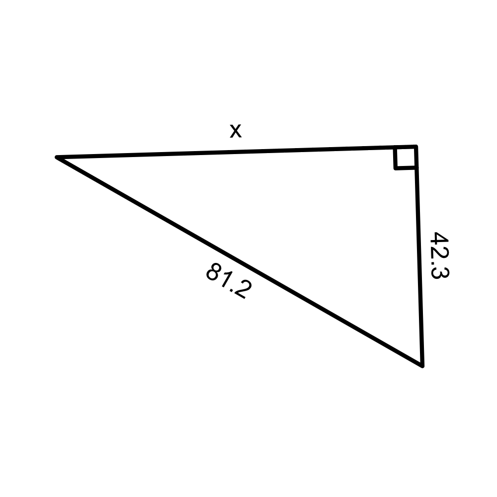

The tolerance is $\pm 0.1$.

Remember pythagorean theorem (for finding a side length from the other two side lengths).

$$(\text{adj})^2+(\text{opp})^2=(\text{hyp})^2$$

Remember SOH-CAH-TOA (for relating side-length ratios to angles).

$$\sin(\theta)=\frac{\text{opp}}{\text{hyp}}$$
$$\cos(\theta)=\frac{\text{adj}}{\text{hyp}}$$
$$\tan(\theta)=\frac{\text{opp}}{\text{adj}}$$

Use the appropriate equation.

$$42.3^2+x^2=81.2^2$$
$$x=\sqrt{6593.44-1789.29}$$

$$x=69.3$$

On the right triangle below, find the unknown length or angle (in degrees).

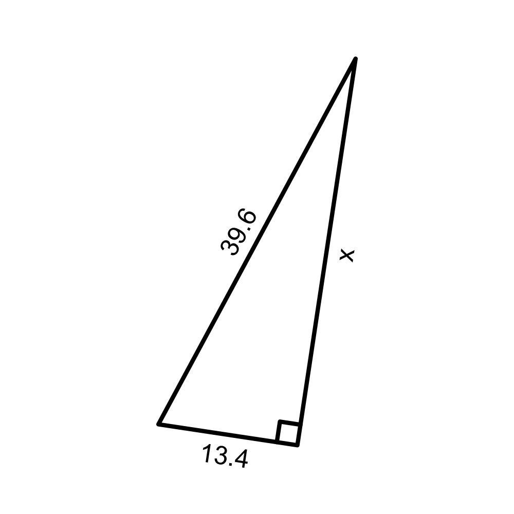

The tolerance is $\pm 0.1$.